# data_analysis_biosamples_psychopathology

Nico Bast

2026-08-24

# 1 SEGA biosamples psychopathology - stress

Aim: Relate biosample data (hair and saliva) and pupillometry (baseline pupil size [BPS] and stimulus‑evoked pupillary response [SEPR]) to transdiagnostic psychopathology in an autism‑enriched sample.

## 1.1 data assembly

- combine different data sources and calculate core variables

### 1.1.1 load data

- utilizes a master file of the SEGA data that contains already preprocessed data

```r
#main data frame as outcome from SEGA data
df<-read.xlsx(paste0(root_path,'/data/master_file_SEGA_Oct2025.xlsx'),na.strings = c("NA","-"),detectDates = T)

#experimental data including SDQ and further cortisol data
df_exp<-read.xlsx(paste0(root_path,'/data/master_file_SEGA_data_Sept2025.xlsx'),startRow = 3)
df_exp<-df_exp[,c(1,3,18:29,42:43,47:56,57:88)] #retain matching, SDQ, height/weight, cortisol, and experimental data

# #comorbidites
df_comorbidity<-read.xlsx(paste0(root_path,'/data/comorbidities_SEGA.xlsx'),detectDates = T)

# baseline pupil size data from raw pupil data
df_baseline<-readRDS(paste0(root_path,'/data/baseline_means.rds'))
```

### 1.1.2 remodel baseline data

```r
#remodel baseline data to match the format

df_baseline<-df_baseline[,names(df_baseline)!='block_counter']

df_baseline <- df_baseline %>%
  tidyr::pivot_wider(
    id_cols = id,
    names_from = baseline_trial_counter,
    values_from = block_baseline_mean
  )


#allign SEGA_ID with other dataframes
names(df_baseline)<-c('SEGA_ID',paste0('BPS_block_',1:6))
df_baseline$sega_id <- sprintf("SEGA_%03d", df_baseline$SEGA_ID)
```

### 1.1.3 rename variables

```r
#saliva samples renaming
names(df_exp)[17:26]<-paste0('saliva_',names(df_exp)[17:26])

names(df)[42:45]<-c('saliva_Value.1','saliva_Value.2','saliva_CV.1','saliva_CV.2')

#hair renaming
names(df)[38]<-'hair_mass_mg'
names(df)[39]<-'hair_cortisol_pg_mg'
names(df)[40]<-'hair_cortisone_pg_mg'

#SDQ
names(df_exp)[3:8]<-c('SDQ_total','SDQ_emo','SDQ_beh','SDQ_hyp','SDQ_beh_peers','SDQ_pros')
names(df_exp)[9:14]<-c('SDQ_total','SDQ_emo','SDQ_beh','SDQ_hyp','SDQ_beh_peers','SDQ_pros')

names(df_exp)[3:8]<-paste0(names(df_exp)[3:8],'_self')
names(df_exp)[9:14]<-paste0(names(df_exp)[9:14],'_parent')
```

### 1.1.4 recode time

- allows to investigate time of day for hormone analysis

```r
#the magic number 86400 is the number of seconds in a day. Multiplying the Excel serial number by this gives us seconds since the Excel epoch ("1899-12-30"). as.POSIXct converts these seconds to a datetime object, and format(..., "%H:%M") extracts just the time string.

# #convert to string "HH:MM" for each time point
# df$saliva_Time.1 <- format(as.POSIXct(df$saliva_Time.1 * 86400, origin = "1899-12-30", tz = "UTC"), "%H:%M")
# df$saliva_Time.2 <- format(as.POSIXct(df$saliva_Time.2 * 86400, origin = "1899-12-30", tz = "UTC"), "%H:%M")

# #convert to numeric fraction of day for each time point
# df$saliva_Time.1 <- as.numeric(difftime(
#   time1 = as.POSIXct(df$saliva_Time.1, format = "%H:%M"),
#   time2 = as.POSIXct("00:00", format = "%H:%M"),
#   units = "secs"
# )) / 86400

# df$saliva_Time.2 <- as.numeric(difftime(
#   time1 = as.POSIXct(df$saliva_Time.2, format = "%H:%M"),
#   time2 = as.POSIXct("00:00", format = "%H:%M"),
#   units = "secs"
# )) / 86400

#convert to string "HH:MM" for each time point
df_exp$saliva_Time.1 <- format(as.POSIXct(df_exp$saliva_Time.1 * 86400, origin = "1899-12-30", tz = "UTC"), "%H:%M")
df_exp$saliva_Time.2 <- format(as.POSIXct(df_exp$saliva_Time.2 * 86400, origin = "1899-12-30", tz = "UTC"), "%H:%M")

#convert to numeric fraction of day for each time point
df_exp$saliva_Time.1 <- as.numeric(difftime(
  time1 = as.POSIXct(df_exp$saliva_Time.1, format = "%H:%M"),
  time2 = as.POSIXct("00:00", format = "%H:%M"),
  units = "secs"
)) / 86400

df_exp$saliva_Time.2 <- as.numeric(difftime(
  time1 = as.POSIXct(df_exp$saliva_Time.2, format = "%H:%M"),
  time2 = as.POSIXct("00:00", format = "%H:%M"),
  units = "secs"
)) / 86400
```

### 1.1.5 merge data

```r
#merge demographics and experimental data
#df<-merge(df,df_exp,by.x='SEGA_ID',by.y='ID_Studie')
df$sega_id <- sprintf("SEGA_%03s", df$sega_id)
df$sega_id<-gsub(' ','0',df$sega_id)
df<-merge(df,df_exp,by.x='sega_id',by.y='ID_Studie')

#merge CBCL factor scores - 4 participants unmatched
#df<-merge(df,df_CBCL_f,by.x='ID-BADO',by.y='ID_Bado')

#merge df_baseline - 10 unmatched
df<-merge(df,df_baseline,by='sega_id',all.x=T)
```

### 1.1.6 calculate age

```r
#merge age
df$age<-as.numeric(with(df,date_data_collection-birthday)/365)
```

### 1.1.7 add comorbidity data

- one or more comorbidities

```r
df_comorbidity$sega_id <- sprintf("SEGA_%03s", df_comorbidity$SEGA_ID)
df_comorbidity$sega_id<-gsub(' ','0',df_comorbidity$sega_id)

df_comorbidity<-df_comorbidity[,names(df_comorbidity)!='group']

df<-merge(df,df_comorbidity,by='sega_id')
```

## 1.2 data manipulation

### 1.2.1 create saliva change variable

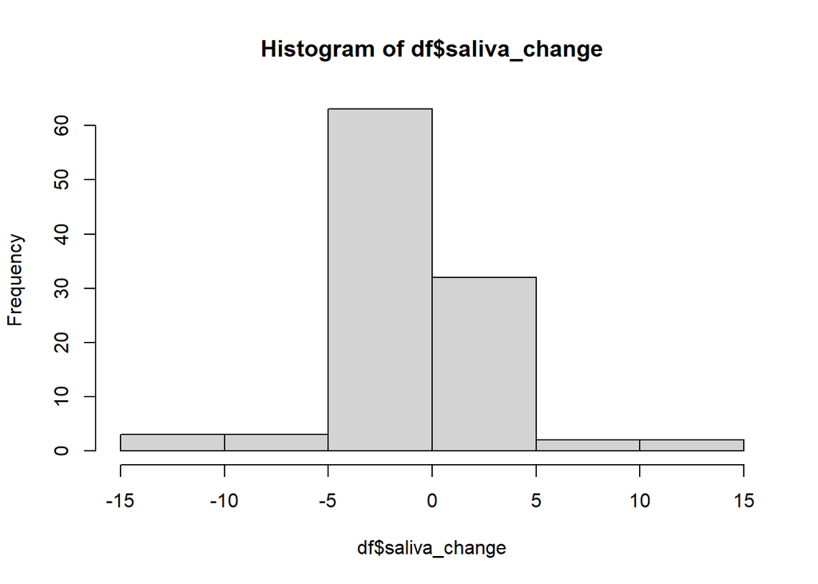

```r
df$saliva_change<-df$saliva_Average.2-df$saliva_Average.1
hist(df$saliva_change)
```

### 1.2.2 recode group variable

```r
table(df$group)
```

```
##
## ASD CON MHC
##  58  57  43
```

```r
df$autism_boolean<-ifelse(df$group=='ASD',T,F)
```

### 1.2.3 logarithmize bio samples

```r
df$saliva_Average.1_log<-log10(df$saliva_Average.1)
df$saliva_Average.2_log<-log10(df$saliva_Average.2)
df$hair_cortisol_pg_mg_log<-log10(df$hair_cortisol_pg_mg)

df$saliva_change_log<-df$saliva_Average.2_log-df$saliva_Average.1_log
df$saliva_change<-df$saliva_Average.2-df$saliva_Average.1
```

### 1.2.4 IQ estimate

- iq estimate based on four Wechsler subtests:
- non-verbal: matrices, block test,
- verbal: commonalities, passive word knowledge

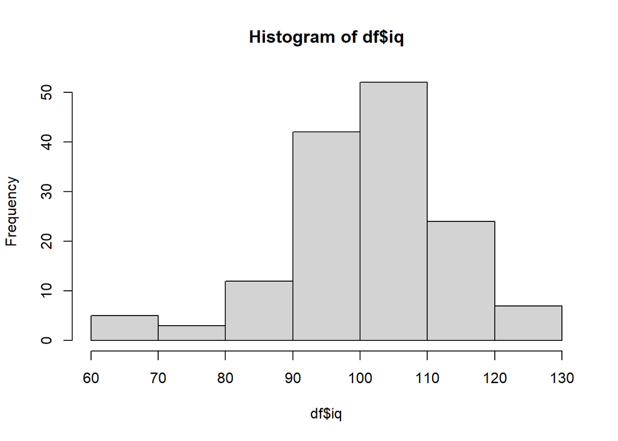

```r
df$iq<-rowMeans(df[,names(df) %in% c('iq_mt','iq_gf','iq_mz','iq_wt')],na.rm=T)
hist(df$iq)
```

### 1.2.5 estimate BMI

```r
df$BMI<-with(df,Gewicht/(Größe/100*Größe/100))
```

### 1.2.6 pupil measure averages

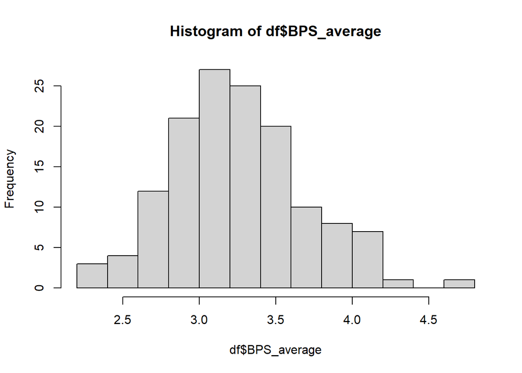

```r
df$BPS_average<-(df$pd_low_oddball_saliencehigh_utilityhigh+
  df$pd_low_oddball_saliencehigh_utilitylow+
  df$pd_low_oddball_saliencelow_utilityhigh+
  df$pd_low_oddball_saliencelow_utilitylow+
  df$BPS_Oddball_before_forward+
  df$BPS_Oddball_after_forward+
  df$BPS_Oddball_before_reverse+
  df$BPS_Oddball_after_reverse)/8


df$SEPR_average<-(df$rpd_oddball_saliencehigh_utilityhigh+
                    df$rpd_oddball_saliencehigh_utilitylow+
                    df$rpd_oddball_saliencelow_utilityhigh+
                    df$rpd_oddball_saliencelow_utilitylow+
                    df$SEPR_Oddball_after_forward+
                    df$SEPR_Oddball_after_reverse+
                    df$SEPR_Oddball_before_forward+
                    df$SEPR_Oddball_before_reverse)/8

hist(df$BPS_average)
```

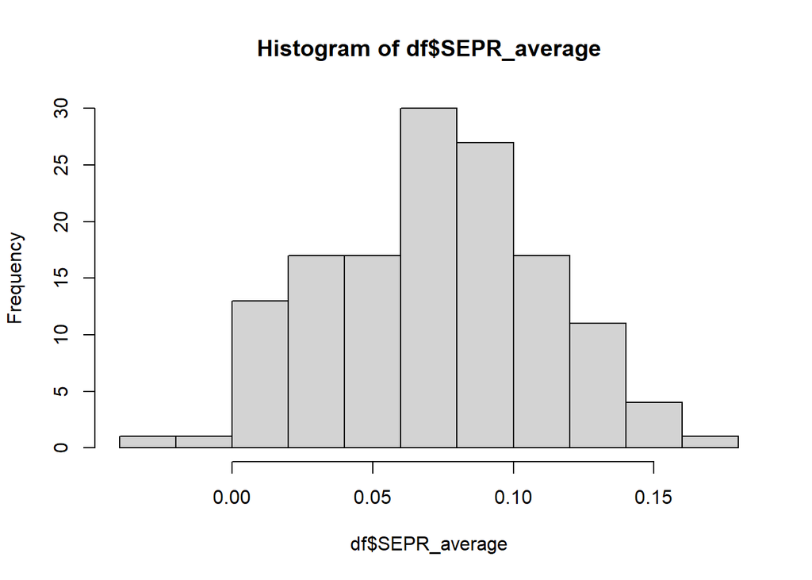

```r
hist(df$SEPR_average)
```

### 1.2.7 pupil size changes

```r
df$SEPR_Oddball_change<-df$SEPR_Oddball_after_forward-df$SEPR_Oddball_before_forward
df$BPS_change<-df$BPS_Standard_after_forward-df$BPS_Standard_before_forward
```

### 1.2.8 pupil variation

```r
df$SEPR_variation<- apply(df[, c(
  "SEPR_Oddball_after_forward",
  "SEPR_Oddball_after_reverse",
  "SEPR_Oddball_before_forward",
  "SEPR_Oddball_before_reverse",
  "rpd_oddball_saliencehigh_utilityhigh",
  "rpd_oddball_saliencehigh_utilitylow",
  "rpd_oddball_saliencelow_utilityhigh",
  "rpd_oddball_saliencelow_utilitylow"
)], 1, sd, na.rm = TRUE)

df$BPS_variation <- apply(df[, c(
  "BPS_block_1",
  "BPS_block_2",
  "BPS_block_3",
  "BPS_block_4",
  "BPS_block_5",
  "BPS_block_6",
  "pd_low_oddball_saliencehigh_utilityhigh",
  "pd_low_oddball_saliencehigh_utilitylow",
  "pd_low_oddball_saliencelow_utilityhigh",
  "pd_low_oddball_saliencelow_utilitylow"
)], 1, sd, na.rm = TRUE)
```

### 1.2.9 SDQ externalizing internalizing - self report

- use Germans norms
- calculate internalizing and externalizing score

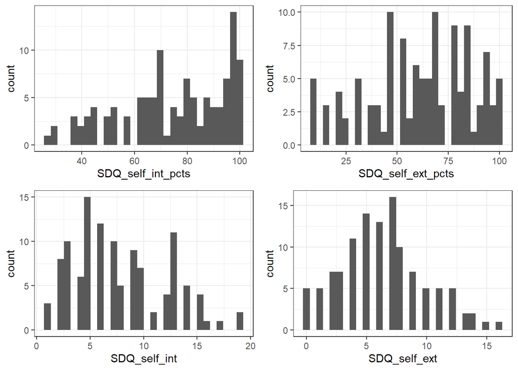

```r
#norms
norms_emo_self <- data.frame(
  raw = 0:10,
  percentile = c(16, 38, 58, 74, 86, 92, 96, 98, 99, 100, 100)
)

norms_beh_peers_self <- data.frame(
  raw = 0:10,
  percentile = c(16, 43, 68, 84, 93, 97, 99, 100, 100, 100, 100)
)

norms_beh_self <- data.frame(
  raw = 0:10,
  percentile = c(12, 43, 72, 88, 95, 98, 99, 100, 100, 100, 100)
)

norms_hyp_self <- data.frame(
  raw = 0:10,
  percentile = c(6, 16, 31, 49, 66, 83, 91, 97, 99, 100, 100)
)

#translate raw to percentiles based on norms
df$pcts_emo_self  <- norms_emo_self$percentile[match(df$SDQ_emo_self, norms_emo_self$raw) ]
df$pcts_beh_peers_self  <- norms_beh_peers_self$percentile[match(df$SDQ_beh_peers_self, norms_beh_peers_self$raw) ]
df$pcts_beh_self  <- norms_beh_self$percentile[match(df$SDQ_beh_self, norms_beh_self$raw) ]
df$pcts_hyp_self  <- norms_hyp_self$percentile[match(df$SDQ_hyp_self, norms_hyp_self$raw) ]

#PERCENTILES: internalizing
df$SDQ_self_int_pcts<-(df$pcts_emo_self+df$pcts_beh_peers_self)/2
df$SDQ_self_ext_pcts<-(df$pcts_beh_self+df$pcts_hyp_self)/2

#RAW: internalizing
df$SDQ_self_int<-df$SDQ_emo_self+df$SDQ_beh_peers_self
df$SDQ_self_ext<-df$SDQ_beh_self+df$SDQ_hyp_self

grid.arrange(
  ggplot(df,aes(SDQ_self_int_pcts))+geom_histogram(),
  ggplot(df,aes(SDQ_self_ext_pcts))+geom_histogram(),
  ggplot(df,aes(SDQ_self_int))+geom_histogram(),
  ggplot(df,aes(SDQ_self_ext))+geom_histogram()
)
```

### 1.2.10 SDQ externalizing internalizing - parent report

- use Germans norms
- calculate internalizing and externalizing score

```r
#norms
norms_emo_parent <- data.frame(
  raw = 0:10,
  percentile = c(16, 38, 58, 74, 86, 92, 96, 98, 99, 100, 100)
)

norms_beh_peers_parent <- data.frame(
  raw = 0:10,
  percentile = c(16, 43, 68, 84, 93, 97, 99, 100, 100, 100, 100)
)

norms_beh_parent <- data.frame(
  raw = 0:10,
  percentile = c(12, 43, 72, 88, 95, 98, 99, 100, 100, 100, 100)
)

norms_hyp_parent <- data.frame(
  raw = 0:10,
  percentile = c(6, 16, 31, 49, 66, 83, 91, 97, 99, 100, 100)
)

#translate raw to percentiles based on norms
df$pcts_emo_parent  <- norms_emo_parent$percentile[match(df$SDQ_emo_parent, norms_emo_parent$raw) ]
df$pcts_beh_peers_parent  <- norms_beh_peers_parent$percentile[match(df$SDQ_beh_peers_parent, norms_beh_peers_parent$raw) ]
df$pcts_beh_parent  <- norms_beh_parent$percentile[match(df$SDQ_beh_parent, norms_beh_parent$raw) ]
df$pcts_hyp_parent  <- norms_hyp_parent$percentile[match(df$SDQ_hyp_parent, norms_hyp_parent$raw) ]

#PERCENTILES: internalizing
df$SDQ_parent_int_pcts<-df$pcts_emo_parent+df$pcts_beh_peers_parent
df$SDQ_parent_ext_pcts<-df$pcts_beh_parent+df$pcts_hyp_parent

#RAW: internalizing
df$SDQ_parent_int<-df$SDQ_emo_parent+df$SDQ_beh_peers_parent
df$SDQ_parent_ext<-df$SDQ_beh_parent+df$SDQ_hyp_parent
```

### 1.2.11 outlier exclusion

- none are excluded

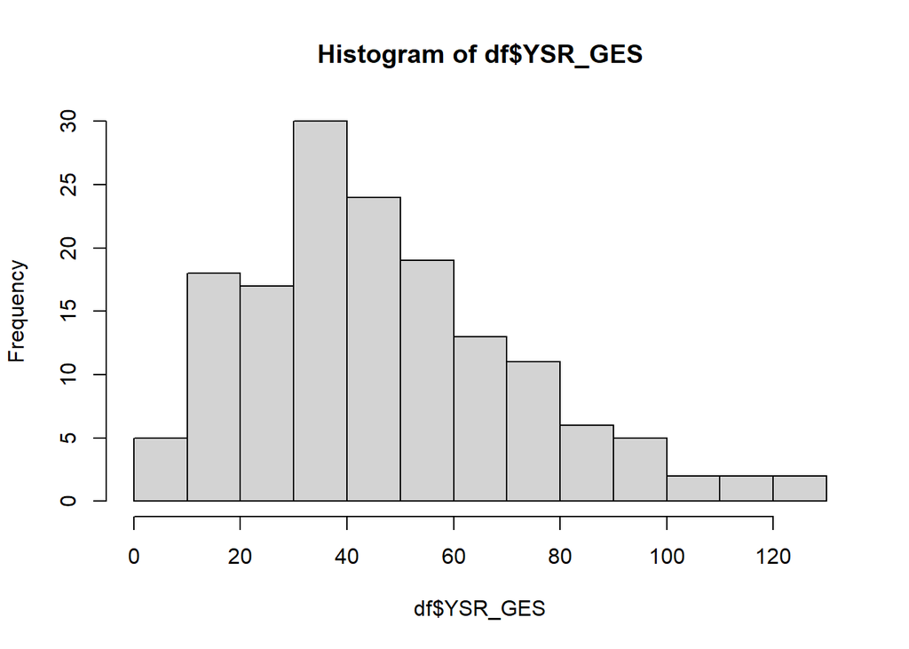

```r
#questionnaires
hist(df$YSR_GES)
```

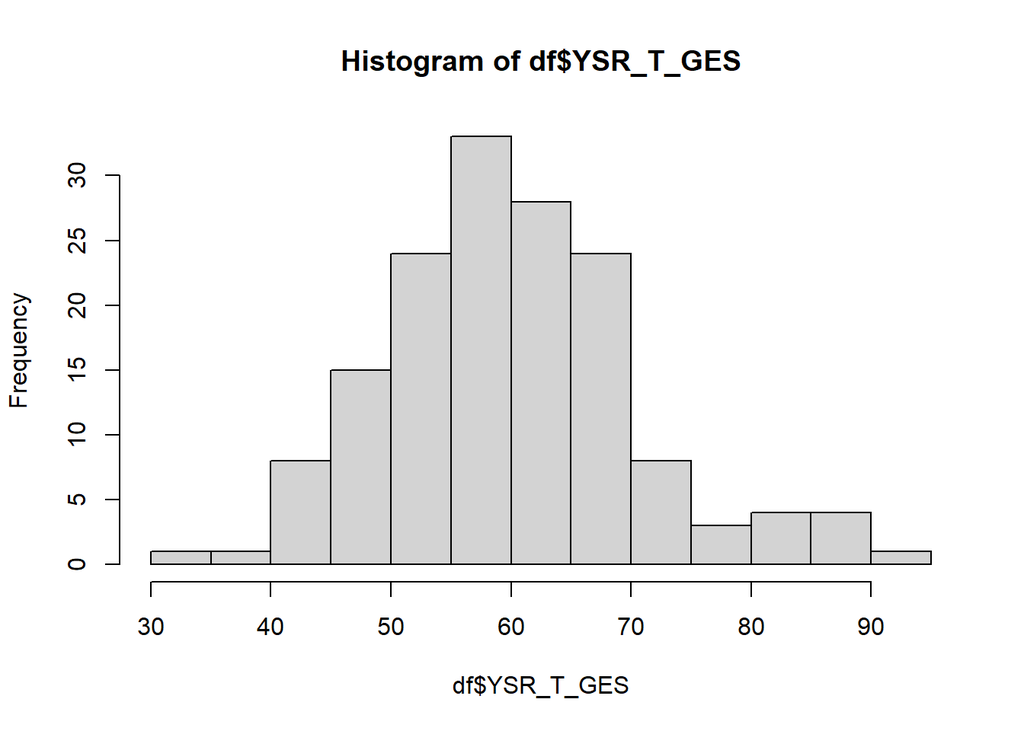

```r
hist(df$YSR_T_GES)
```

```r
# #correct typo
# df$YSR_GES[df$YSR_T_GES>100 & !is.na(df$YSR_T_GES)]
# df$YSR_GES[df$YSR_T_GES<25 & !is.na(df$YSR_T_GES)]

# df$YSR_T_GES[which(df$YSR_T_GES>100)]<-48
# df$YSR_T_GES[which(df$YSR_T_GES<25)]<-89
```

## 1.3 data quality

### 1.3.1 missing data

-complete data for CBCL -more missings in SDQ

```r
CBCL<-with(df,table(!is.na(CBCL_T_GES)))
# CBCL_factor<-with(df,table(!is.na(cbcl_P_f)))
# CBCL_factor<-c(FALSE,CBCL_factor)

YSR<-with(df,table(!is.na(YSR_T_GES)))

SDQ_self<-with(df,table(!is.na(SDQ_total_self)))
SDQ_parent<-with(df,table(!is.na(SDQ_total_parent)))

hair_cortisol<-with(df,table(!is.na(hair_cortisol_pg_mg)))
saliva_cortisol_measure1<-with(df,table(!is.na(saliva_Average.1)))
saliva_cortisol_measure2<-with(df,table(!is.na(saliva_Average.2)))

BPS_average_mis<-with(df,table(!is.na(BPS_average)))
SEPR_average_mis<-with(df,table(!is.na(SEPR_average)))

missing_table<-rbind(CBCL, YSR,SDQ_self,SDQ_parent,hair_cortisol,saliva_cortisol_measure1,saliva_cortisol_measure2,
                     BPS_average_mis,SEPR_average_mis)

missing_table %>%
  kbl(caption = "Available data for data modalities") %>%
  kable_classic(full_width = F, html_font = "Cambria")
```

Available data for data modalities

|  | FALSE | TRUE |
| --- | --- | --- |
| CBCL | 3 | 155 |
| YSR | 4 | 154 |
| SDQ_self | 41 | 117 |
| SDQ_parent | 42 | 116 |
| hair_cortisol | 49 | 109 |
| saliva_cortisol_measure1 | 49 | 109 |
| saliva_cortisol_measure2 | 51 | 107 |
| BPS_average_mis | 19 | 139 |
| SEPR_average_mis | 19 | 139 |

```r
with(df,table(!is.na(YSR_T_GES),!is.na(hair_cortisol_pg_mg)))
```

```
##
##         FALSE TRUE
##   FALSE     1    3
##   TRUE     48  106
```

```r
with(df,table(!is.na(SDQ_total_parent),!is.na(hair_cortisol_pg_mg)))
```

```
##
##         FALSE TRUE
##   FALSE    38    4
##   TRUE     11  105
```

```r
with(df,table(!is.na(hair_cortisol_pg_mg),!is.na(BPS_average)))
```

```
##
##         FALSE TRUE
##   FALSE     6   43
##   TRUE     13   96
```

```r
with(df,table(!is.na(hair_cortisol_pg_mg),!is.na(saliva_Average.1)))
```

```
##
##         FALSE TRUE
##   FALSE    32   17
##   TRUE     17   92
```

### 1.3.2 participants by diagnosis and available biosamples

```r
table(df$group[!is.na(df$hair_cortisol_pg_mg) & !is.na(df$saliva_Average.1)])
```

```
##
## ASD CON MHC
##  37  21  34
```

### 1.3.3 bio samples data quality

#### 1.3.3.1 hair cortisol

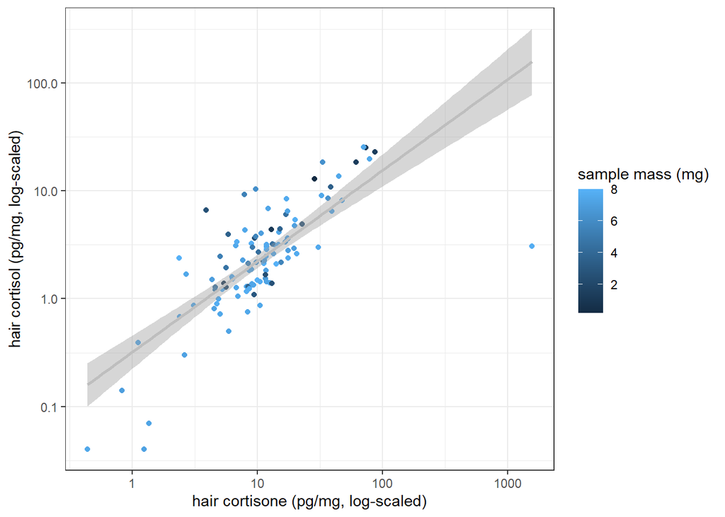

```r
ggplot(df,aes(x=hair_cortisone_pg_mg,y=hair_cortisol_pg_mg,color=hair_mass_mg))+
  geom_point()+
  labs(x='hair cortisone (pg/mg, log-scaled)', y='hair cortisol (pg/mg, log-scaled)', color='sample mass (mg)')+
  geom_smooth(color='grey',method='lm')+
  scale_x_continuous(trans='log10') +
  scale_y_continuous(trans='log10')
```

#### 1.3.3.2 saliva cortisol

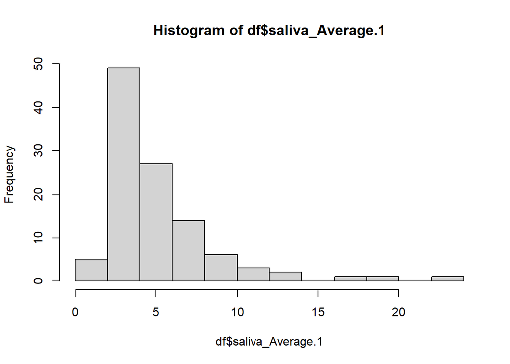

```r
hist(df$saliva_Average.1)
```

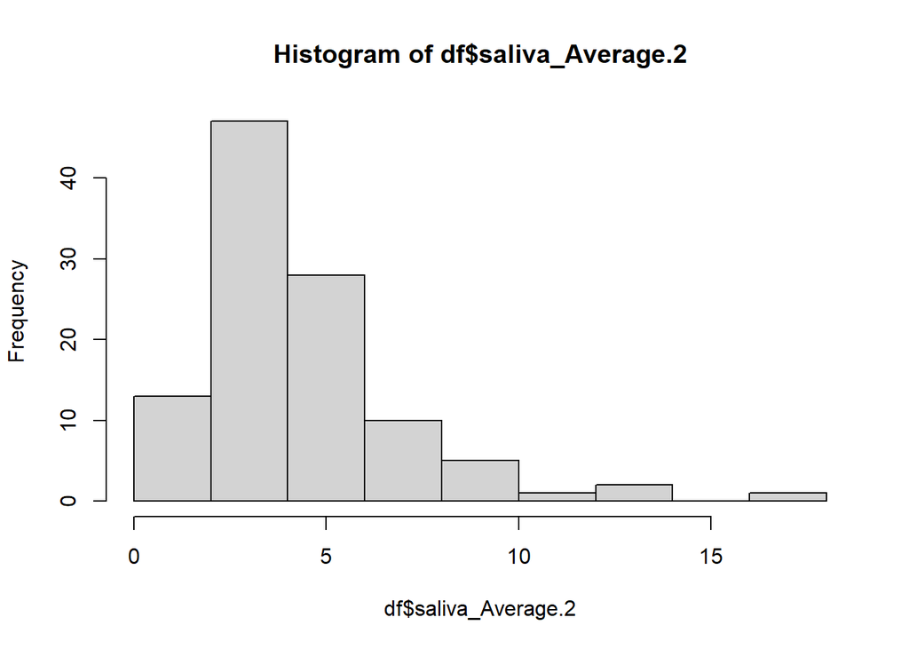

```r
hist(df$saliva_Average.2)
```

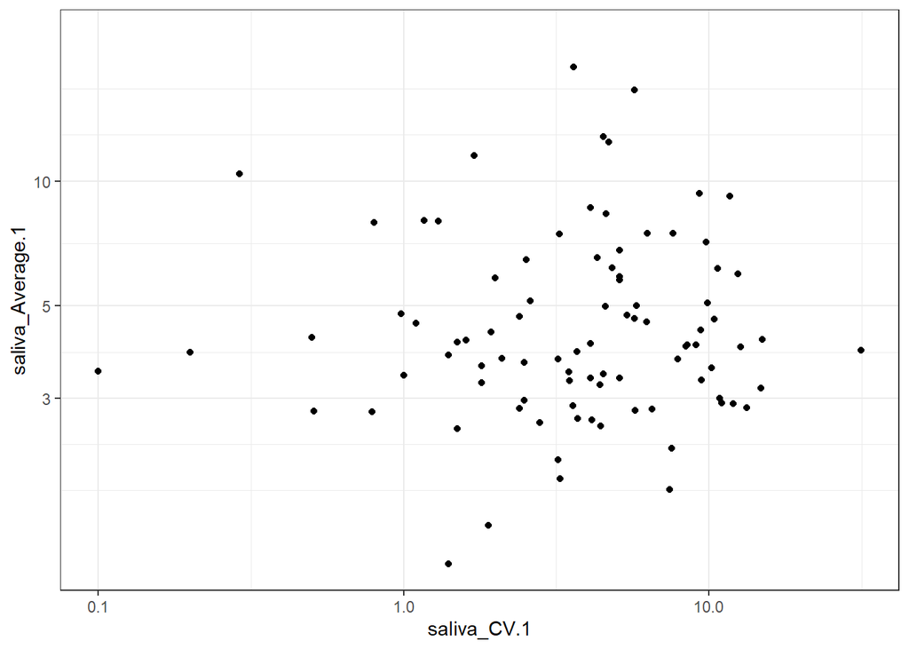

```r
ggplot(df,aes(y=saliva_Average.1,x=saliva_CV.1))+
  geom_point()+
  scale_x_continuous(trans='log10') +
  scale_y_continuous(trans='log10')
```

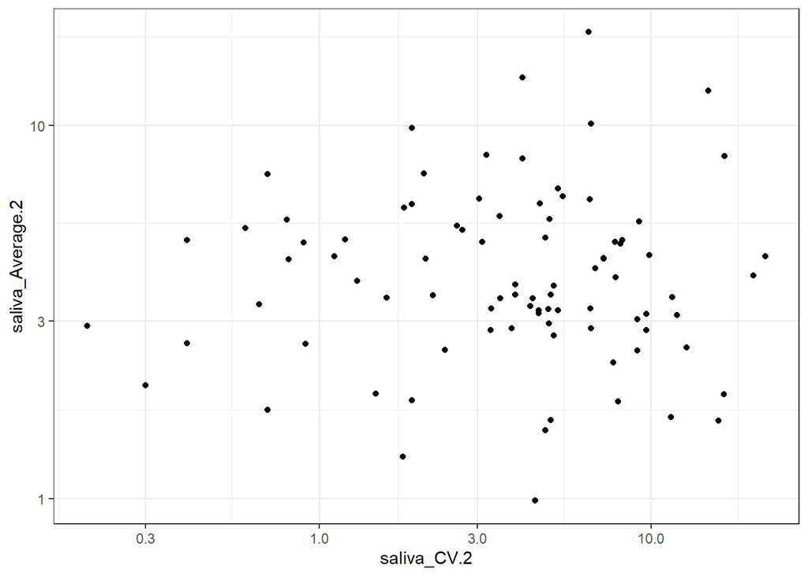

```r
ggplot(df,aes(y=saliva_Average.2,x=saliva_CV.2))+
  geom_point()+
  scale_x_continuous(trans='log10') +
  scale_y_continuous(trans='log10')
```

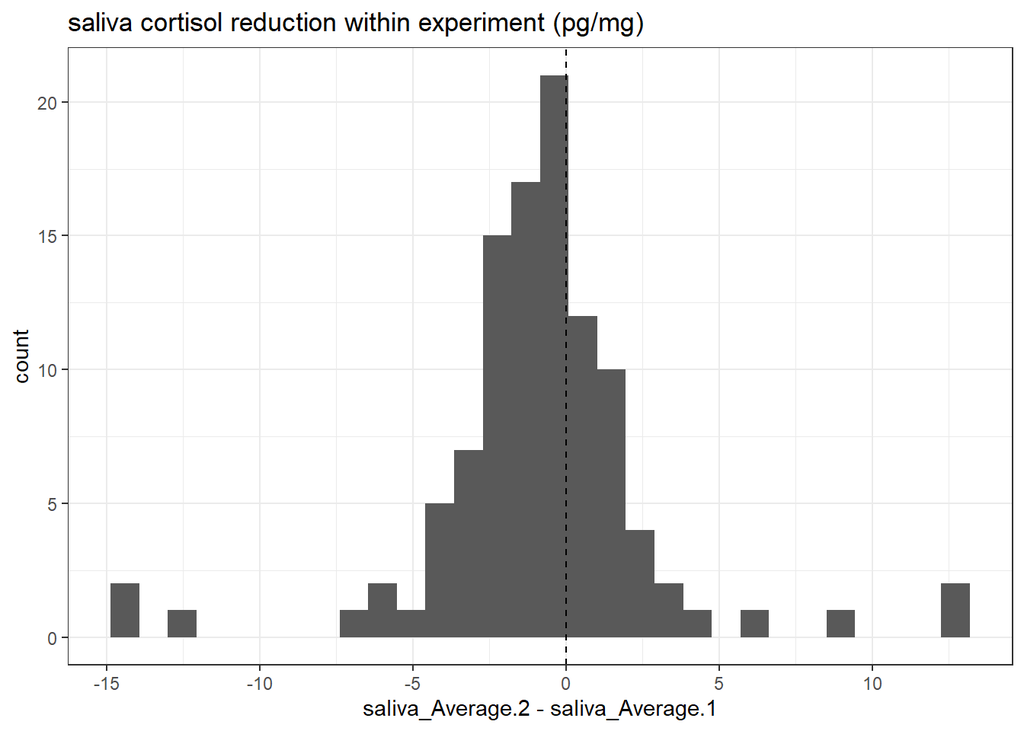

```r
ggplot(df,aes(x=saliva_Average.2-saliva_Average.1))+
  geom_histogram()+
  geom_vline(xintercept=0,linetype=2)+
  labs(title='saliva cortisol reduction within experiment (pg/mg)')
```

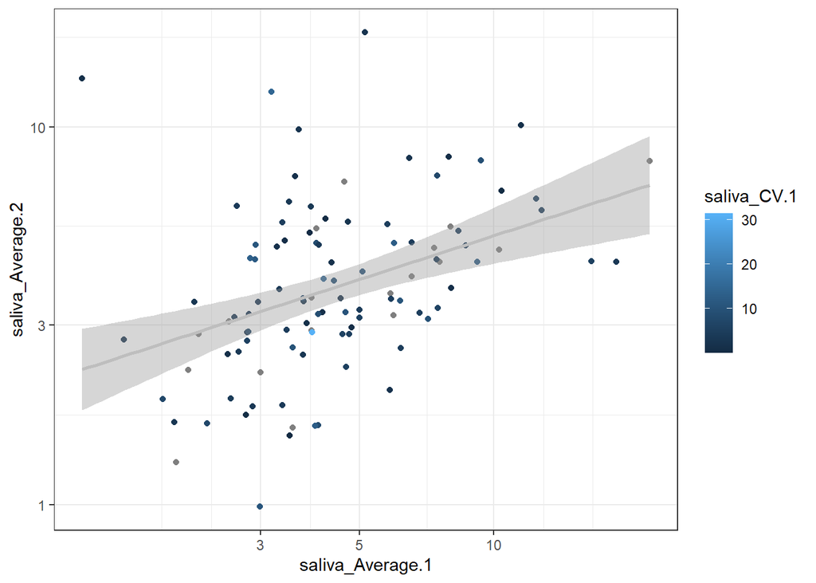

```r
ggplot(df,aes(x=saliva_Average.1,y=saliva_Average.2,color=saliva_CV.1))+
  geom_point()+
  geom_smooth(color='grey',method='lm')+
  #labs(x='hair cortisone (pg/mg, log-scaled)', y='hair cortisol (pg/mg, log-scaled)', color='sample mass (mg)')+
  scale_x_continuous(trans='log10') +
  scale_y_continuous(trans='log10')
```

##### 1.3.3.2.1 intra- inter-assay coefficient of variation (CV)

```r
psych::describe(df$saliva_CV.1)
```

```
##    vars   n mean   sd median trimmed  mad min  max range skew kurtosis   se
## X1    1 108 5.36 4.51   4.42     4.8 3.72 0.1 31.4  31.3 2.18     8.68 0.43
```

```r
psych::describe(df$saliva_CV.2)
```

```
##    vars   n mean   sd median trimmed  mad min   max range skew kurtosis   se
## X1    1 106 5.67 4.38    4.8    5.11 4.23 0.2 22.09 21.89  1.3     1.91 0.43
```

### 1.3.4 bio samples

- suggests to log-transform variables in analysis

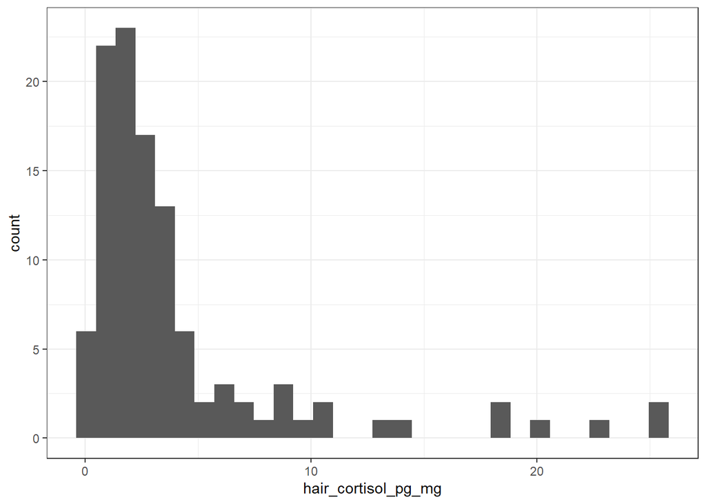

```r
ggplot(df,aes(hair_cortisol_pg_mg))+geom_histogram()
```

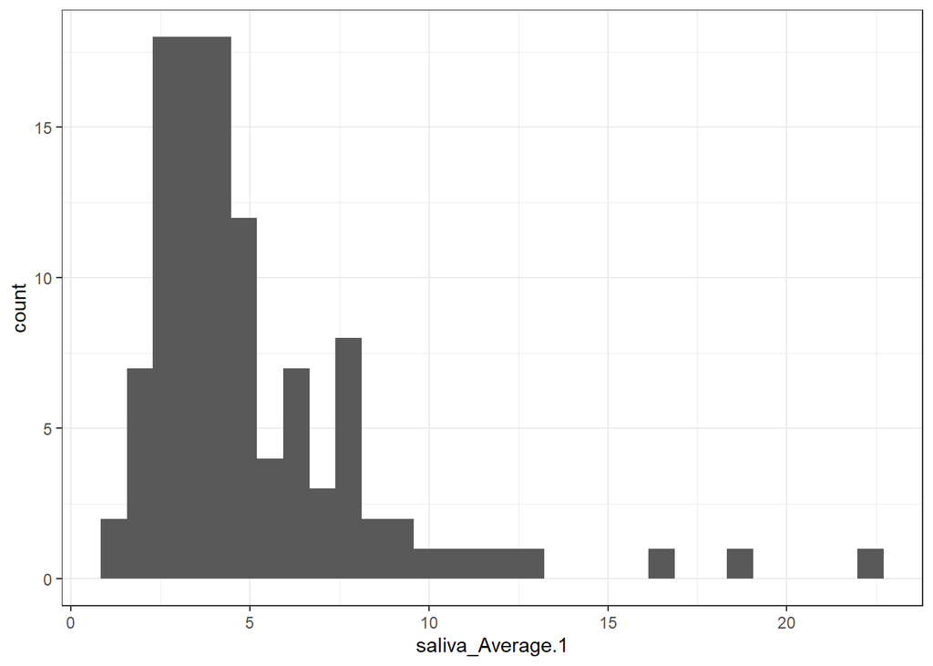

```r
ggplot(df,aes(saliva_Average.1))+geom_histogram()
```

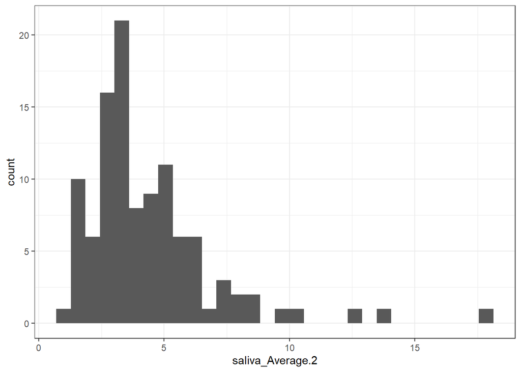

```r
ggplot(df,aes(saliva_Average.2))+geom_histogram()
```

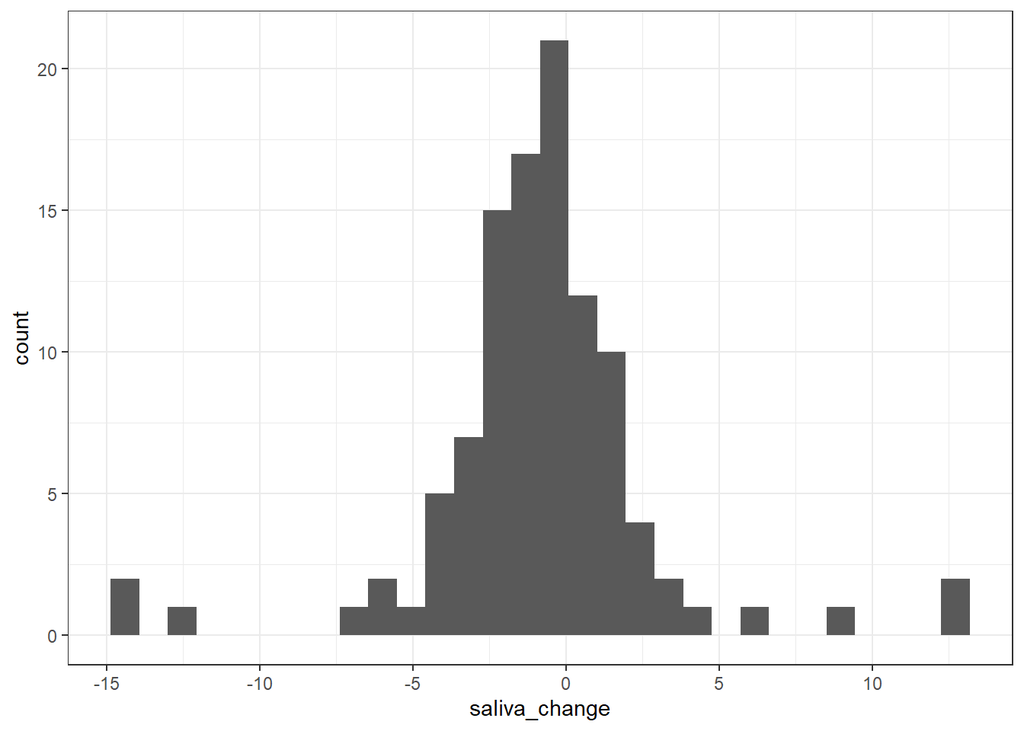

```r
ggplot(df,aes(saliva_change))+geom_histogram()
```

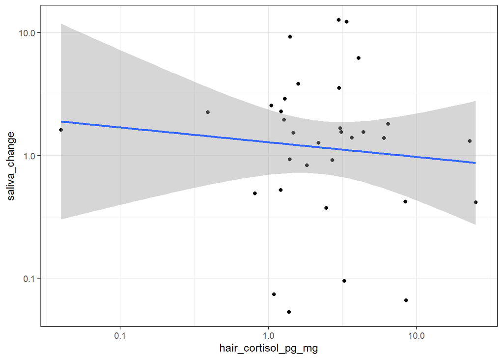

```r
ggplot(df,aes(x=hair_cortisol_pg_mg,y=saliva_change))+geom_point()+
  scale_x_continuous(trans='log10')+
  scale_y_continuous(trans='log10')+
  geom_smooth(method='lm')
```

## 1.4 data analysis

### 1.4.1 sample definition

- define sample as participants with self-reported psychopathology and saliva cortisol

```r
df_sample<-df[!is.na(df$YSR_T_GES) & !is.na(df$saliva_Average.1),]

#total sample
nrow(df_sample)
```

```
## [1] 106
```

### 1.4.2 sample description

```r
table(df_sample$gender)
```

```
##
## männlich weiblich
##       56       50
```

```r
table_data<-rbind(psych::describe(df_sample$age),
                  psych::describe(df_sample$iq),
                  psych::describe(df_sample$YSR_T_GES),
                  psych::describe(df_sample$YSR_T_INT),
                  psych::describe(df_sample$YSR_T_EXT),
                  psych::describe(df_sample$CBCL_T_GES),
                  psych::describe(df_sample$CBCL_T_INT),
                  psych::describe(df_sample$CBCL_T_EXT),
                  psych::describe(df_sample$SDQ_total_self),
                  psych::describe(df_sample$SDQ_self_int),
                  psych::describe(df_sample$SDQ_self_ext),
                  psych::describe(df_sample$SDQ_total_parent),
                  psych::describe(df_sample$SDQ_parent_int),
                  psych::describe(df_sample$SDQ_parent_ext),
                  psych::describe(df_sample$hair_cortisol_pg_mg),
                  psych::describe(df_sample$saliva_Average.1),
                  psych::describe(df_sample$saliva_Average.2))


table_data<-table_data[,c('n','mean','sd','min','max')]
table_data<-round(table_data,2)

row.names(table_data)<-c('age','iq','YSR TOTAL (t)','YSR INT (t)','YSR EXT (t)',
                         'CBCL TOTAL (t)','CBCL INT (t)','CBCL EXT (t)',
                         'SDQ TOTAL self (sum)','SDQ INT self (sum)','SDQ EXT self (sum)',
                         'SDQ TOTAL parent (sum)','SDQ INT parent (sum)','SDQ EXT parent (sum)',
                         'hair cortisol (pg/mg)','saliva cortisol before (nmol/l)','saliva cortisol after (nmol/l)')


table_sample<-table_data %>%
  kbl(caption = "Table 1. Sample description") %>%
  kable_classic(full_width = F, html_font = "Cambria")


table_sample
```

Table 1. Sample description

|  | n | mean | sd | min | max |
| --- | --- | --- | --- | --- | --- |
| age | 106 | 15.35 | 1.95 | 11.93 | 18.84 |
| iq | 97 | 100.44 | 12.16 | 61.25 | 125.00 |
| YSR TOTAL (t) | 106 | 61.31 | 10.31 | 40.00 | 91.00 |
| YSR INT (t) | 106 | 62.74 | 12.61 | 34.00 | 94.00 |
| YSR EXT (t) | 106 | 54.51 | 7.53 | 31.00 | 70.00 |
| CBCL TOTAL (t) | 105 | 61.00 | 11.90 | 31.00 | 84.00 |
| CBCL INT (t) | 105 | 62.83 | 12.41 | 36.00 | 87.00 |
| CBCL EXT (t) | 105 | 54.65 | 10.41 | 36.00 | 81.00 |
| SDQ TOTAL self (sum) | 94 | 14.13 | 6.17 | 1.00 | 30.00 |
| SDQ INT self (sum) | 93 | 7.92 | 4.13 | 1.00 | 19.00 |
| SDQ EXT self (sum) | 94 | 6.26 | 3.43 | 0.00 | 15.00 |
| SDQ TOTAL parent (sum) | 93 | 12.30 | 7.17 | 0.00 | 28.00 |
| SDQ INT parent (sum) | 93 | 7.16 | 4.68 | 0.00 | 16.00 |
| SDQ EXT parent (sum) | 93 | 5.14 | 3.84 | 0.00 | 15.00 |
| hair cortisol (pg/mg) | 89 | 4.07 | 5.12 | 0.04 | 25.39 |
| saliva cortisol before (nmol/l) | 106 | 5.17 | 3.41 | 1.19 | 22.34 |
| saliva cortisol after (nmol/l) | 102 | 4.35 | 2.63 | 0.99 | 17.84 |

```r
save_kable(table_sample, file=paste0(project_path,'/output/tables/table1_sampledescription.html'))
```

### 1.4.3 comorbidities

```r
#with primary diagnosis
table(df_sample$group=='CON')
```

```
##
## FALSE  TRUE
##    76    30
```

```r
#primnary diagnosis
table(df_sample$primary.diagnosis)
```

```
##
## ADHD  ANG  ASD DEPR
##   11    9   42   14
```

```r
#comorbdiity
table(!is.na(df_sample$other.diagnoses))
```

```
##
## FALSE  TRUE
##    57    49
```

```r
table(c(df_sample$other.diagnoses,df_sample$other.diagnoses.1))
```

```
##
## F29 F32 F40 F41 F43 F45 F50 F80 F81 F83 F90 F91 F93 F95 F98
##   1   4   9   3   1   1   5   3   5   1  12   7   7   4   9
```

### 1.4.4 figure questionnaire data

```r
bin_count<-15

tiff(file=paste0(project_path,"/output/figures/figure_questionnaire_distribution.tiff"),
     width=8, height=4, units="in", res=600, compression='lzw')

#core questionnaire measures
grid.arrange(
  ggplot(df_sample,aes(YSR_GES,group=Gruppe))+
    geom_histogram(bins=bin_count)+ylim(0,20)+theme(axis.title.y = element_blank())+xlab('YSR Total'),
  ggplot(df_sample,aes(YSR_INT,group=Gruppe))+
    geom_histogram(bins=bin_count)+ylim(0,20)+xlim(0,50)+theme(axis.title.y = element_blank())+xlab('YSR Internalizing'),
  ggplot(df_sample,aes(YSR_EXT,group=Gruppe))+
    geom_histogram(bins=bin_count)+ylim(0,32)+xlim(0,50)+theme(axis.title.y = element_blank())+xlab('YSR Externalizing'),

  ggplot(df_sample,aes(SDQ_total_self,group=Gruppe))+
    geom_histogram(bins=bin_count)+xlim(0,35)+ylim(0,20)+theme(axis.title.y = element_blank())+xlab('SDQ-s Total'),
  ggplot(df_sample,aes(SDQ_self_int,group=Gruppe))+
    geom_histogram(bins=bin_count)+xlim(0,20)+ylim(0,20)+theme(axis.title.y = element_blank())+xlab('SDQ-s Internalizing'),
  ggplot(df_sample,aes(SDQ_self_ext,group=Gruppe))+
    geom_histogram(bins=bin_count)+xlim(0,20)+ylim(0,20)+theme(axis.title.y = element_blank())+xlab('SDQ-s Externalizing'),

nrow=2)
dev.off()
```

```r
#print to markdown
knitr::include_graphics(paste0(project_path,"/output/figures/figure_questionnaire_distribution.tiff"))
```

[figure not shown]

### 1.4.5 CBCL and SDQ correlation

- does not suggest collapsing SDQ and CBCL/YSR reports of internalizing and externalizing

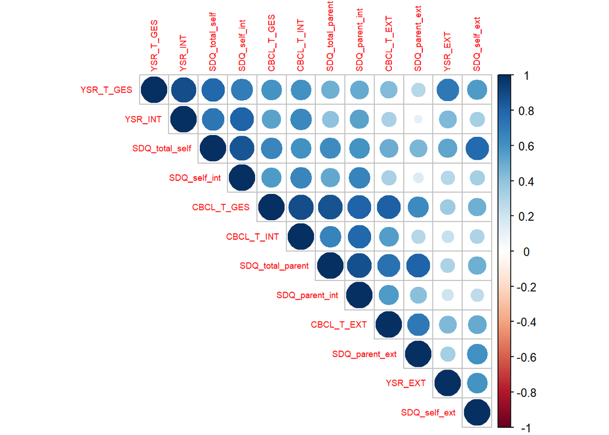

```r
interested_variables<-c(
  "YSR_T_GES",
  "YSR_INT",
  "YSR_EXT",
  "CBCL_T_GES",
  "CBCL_T_INT",
  "CBCL_T_EXT",
  "SDQ_total_self",
  "SDQ_self_int",
  "SDQ_self_ext",
  "SDQ_total_parent",
  "SDQ_parent_int",
  "SDQ_parent_ext"

)

cor_matrix<-round(cor(df_sample[,interested_variables],use = 'pairwise.complete.obs'),2)
corrplot(cor_matrix,type='upper',order='hclust',tl.cex=0.6)
```

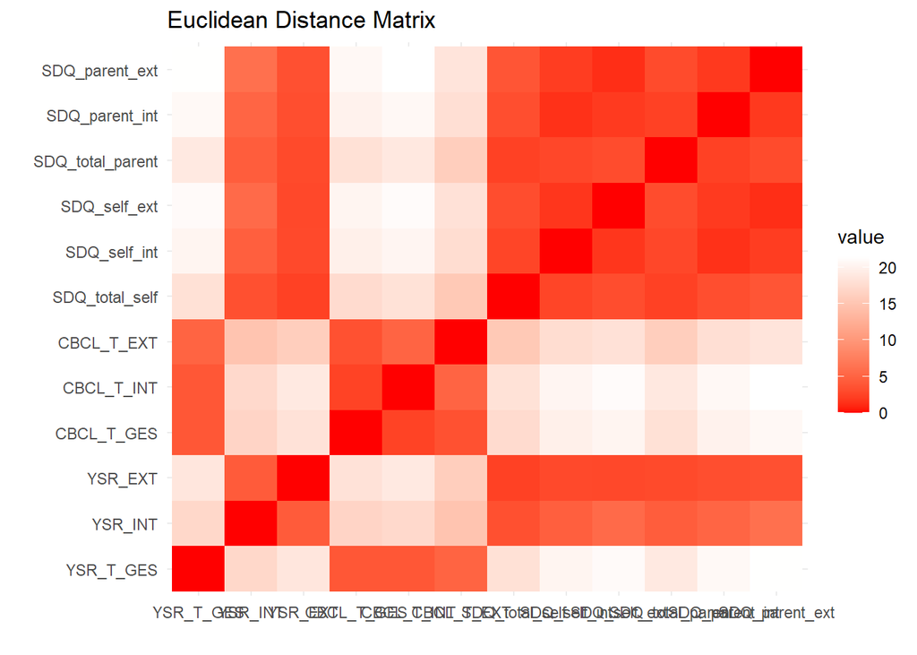

```r
df_cluster<-t(df_sample[complete.cases(df_sample[,interested_variables]),interested_variables])
df_cluster<-scale(df_cluster)
dist_matrix<-dist(df_cluster, method='euclidean')
dist_mat <- as.matrix(dist_matrix)

melted_dist <- reshape2::melt(dist_mat)
ggplot(melted_dist, aes(Var1, Var2, fill = value)) +
  geom_tile() +
  scale_fill_gradient(low = "red", high = "white") +
  theme_minimal() +
  labs(title = "Euclidean Distance Matrix", x = "", y = "")
```

```r
### difference SDQ CBCL/YSR
cor.test(df_sample$YSR_INT,df_sample$SDQ_self_int)
```

```
##
##  Pearson's product-moment correlation
##
## data:  df_sample$YSR_INT and df_sample$SDQ_self_int
## t = 12.534, df = 91, p-value < 2.2e-16
## alternative hypothesis: true correlation is not equal to 0
## 95 percent confidence interval:
##  0.7065781 0.8600440
## sample estimates:
##       cor
## 0.7957495
```

```r
cor.test(df_sample$CBCL_INT,df_sample$SDQ_parent_int)
```

```
##
##  Pearson's product-moment correlation
##
## data:  df_sample$CBCL_INT and df_sample$SDQ_parent_int
## t = 11.086, df = 90, p-value < 2.2e-16
## alternative hypothesis: true correlation is not equal to 0
## 95 percent confidence interval:
##  0.6572478 0.8347083
## sample estimates:
##      cor
## 0.759786
```

```r
cor.test(df_sample$YSR_EXT,df_sample$SDQ_self_ext)
```

```
##
##  Pearson's product-moment correlation
##
## data:  df_sample$YSR_EXT and df_sample$SDQ_self_ext
## t = 7.0882, df = 92, p-value = 2.701e-10
## alternative hypothesis: true correlation is not equal to 0
## 95 percent confidence interval:
##  0.4453320 0.7112862
## sample estimates:
##       cor
## 0.5943222
```

```r
cor.test(df_sample$CBCL_EXT,df_sample$SDQ_parent_ext)
```

```
##
##  Pearson's product-moment correlation
##
## data:  df_sample$CBCL_EXT and df_sample$SDQ_parent_ext
## t = 10.111, df = 90, p-value < 2.2e-16
## alternative hypothesis: true correlation is not equal to 0
## 95 percent confidence interval:
##  0.6165385 0.8126941
## sample estimates:
##       cor
## 0.7292658
```

```r
#concordance
cor.test(df_sample$YSR_INT,df_sample$CBCL_INT)
```

```
##
##  Pearson's product-moment correlation
##
## data:  df_sample$YSR_INT and df_sample$CBCL_INT
## t = 9.0352, df = 103, p-value = 1.03e-14
## alternative hypothesis: true correlation is not equal to 0
## 95 percent confidence interval:
##  0.5423964 0.7597719
## sample estimates:
##       cor
## 0.6649359
```

```r
cor.test(df_sample$YSR_EXT,df_sample$CBCL_EXT)
```

```
##
##  Pearson's product-moment correlation
##
## data:  df_sample$YSR_EXT and df_sample$CBCL_EXT
## t = 4.7849, df = 103, p-value = 5.732e-06
## alternative hypothesis: true correlation is not equal to 0
## 95 percent confidence interval:
##  0.2556806 0.5714088
## sample estimates:
##       cor
## 0.4264477
```

```r
cor.test(df_sample$SDQ_parent_int,df_sample$SDQ_self_int)
```

```
##
##  Pearson's product-moment correlation
##
## data:  df_sample$SDQ_parent_int and df_sample$SDQ_self_int
## t = 8.3624, df = 89, p-value = 7.811e-13
## alternative hypothesis: true correlation is not equal to 0
## 95 percent confidence interval:
##  0.5297505 0.7647941
## sample estimates:
##       cor
## 0.6633268
```

```r
cor.test(df_sample$SDQ_parent_ext,df_sample$SDQ_self_ext)
```

```
##
##  Pearson's product-moment correlation
##
## data:  df_sample$SDQ_parent_ext and df_sample$SDQ_self_ext
## t = 7.0794, df = 90, p-value = 3.072e-10
## alternative hypothesis: true correlation is not equal to 0
## 95 percent confidence interval:
##  0.4481470 0.7152693
## sample estimates:
##       cor
## 0.5980687
```

### 1.4.6 table pupil measures descriptives

```r
table_data<-rbind(psych::describe(df_sample$BPS_average),
                  psych::describe(df_sample$BPS_block_1),
                  psych::describe(df_sample$BPS_block_3),
                  psych::describe(df_sample$BPS_block_4),
                  psych::describe(df_sample$BPS_block_6),
                  psych::describe(df_sample$pd_low_standard_saliencehigh_utilityhigh),
                  psych::describe(df_sample$pd_low_standard_saliencehigh_utilitylow),
                  psych::describe(df_sample$pd_low_standard_saliencelow_utilityhigh),
                  psych::describe(df_sample$pd_low_standard_saliencelow_utilitylow),
                  psych::describe(df_sample$SEPR_average),
                  psych::describe(df_sample$SEPR_Oddball_before_forward),
                  psych::describe(df_sample$SEPR_Oddball_after_forward),
                  psych::describe(df_sample$rpd_oddball_saliencehigh_utilityhigh),
                  psych::describe(df_sample$rpd_oddball_saliencehigh_utilitylow),
                  psych::describe(df_sample$rpd_oddball_saliencelow_utilityhigh),
                  psych::describe(df_sample$rpd_oddball_saliencelow_utilitylow)
                  )


table_data<-table_data[,c('n','mean','sd','min','max')]
table_data<-round(table_data,2)

row.names(table_data)<-c('BPS average','BPS auditory oddball before task','BPS auditory oddball before manipulaiton','BPS auditory oddball after manipulation','BPS auditory oddball after task',
                         'BPS visual oddball ++','BPS visual oddball +-','BPS visual oddball -+','BPS visual oddball --',
                         'SEPR average','SEPR auditory oddball before manipulation','SEPR auditory oddball after manipulation',
                         'SEPR viusal oddball ++','SEPR viusal oddball +-','SEPR viusal oddball -+','SEPR viusal oddball --')


measure<-c('BPS (in mm)','','','','','','','','',
           'SEPR (in mm)','','','','','','')


task<-c('','auditory','auditory','auditory','auditory','visual','visual','visual','visual',
        '','auditory','auditory','visual','visual','visual','visual')

condition<-c('','before task','before manipulation','after manipulation','after task','salience high + utility high','salience high + utility low','salience low + utility high','salience low + utility low',
            '','before manipulation','after manipulation','salience high + utility high','salience high + utility low','salience low + utility high','salience low + utility low')


table_data<-cbind(measure,task,condition,table_data)

table_sample<-table_data %>%
  kbl(caption = "Table 1. Description of pupillary measures", row.names = F) %>%
  kable_classic(full_width = F, html_font = "Cambria") %>%
  footnote(general = "++ = salience high, utility high, +- = salience high, utility low, -+ = salience low, utility high, -- = salience low, utility low")

table_sample
```

Table 1. Description of pupillary measures

| measure | task | condition | n | mean | sd | min | max |
| --- | --- | --- | --- | --- | --- | --- | --- |
| BPS (in mm) |  |  | 96 | 3.23 | 0.41 | 2.26 | 4.27 |
|  | auditory | before task | 102 | 3.87 | 0.52 | 2.59 | 5.06 |
|  | auditory | before manipulation | 102 | 3.57 | 0.51 | 2.31 | 4.59 |
|  | auditory | after manipulation | 102 | 3.37 | 0.51 | 2.21 | 4.46 |
|  | auditory | after task | 102 | 3.58 | 0.48 | 2.47 | 4.68 |
|  | visual | salience high + utility high | 98 | 3.45 | 0.44 | 2.24 | 4.58 |
|  | visual | salience high + utility low | 98 | 3.47 | 0.44 | 2.42 | 4.58 |
|  | visual | salience low + utility high | 98 | 3.27 | 0.42 | 2.26 | 4.46 |
|  | visual | salience low + utility low | 98 | 3.27 | 0.41 | 2.33 | 4.42 |
| SEPR (in mm) |  |  | 96 | 0.08 | 0.04 | 0.01 | 0.16 |
|  | auditory | before manipulation | 102 | 0.04 | 0.04 | -0.06 | 0.17 |
|  | auditory | after manipulation | 102 | 0.03 | 0.04 | -0.05 | 0.16 |
|  | visual | salience high + utility high | 98 | 0.16 | 0.07 | -0.01 | 0.31 |
|  | visual | salience high + utility low | 98 | 0.14 | 0.07 | -0.02 | 0.29 |
|  | visual | salience low + utility high | 98 | 0.11 | 0.08 | -0.07 | 0.34 |
|  | visual | salience low + utility low | 98 | 0.09 | 0.08 | -0.08 | 0.26 |

Note:  
++ = salience high, utility high, +- = salience high, utility low, -+ = salience low, utility high, – = salience low, utility low

```r
save_kable(table_sample, file=paste0(project_path,'/output/tables/tablex_pupildescription.html'))
```

### 1.4.7 figure pupil measure and bio samples

```r
tiff(file=paste0(project_path,"/output/figures/figure_pupillometry_biosamples.tiff"),
     width=8, height=5.5, units="in", res=600, compression='lzw')

composite_bins<-12

grid.arrange(

ggplot(df_sample,aes(x=BPS_average))+
  geom_histogram(bins=composite_bins)+xlab('BPS: baseline pupil size [mm]')+ylim(0,20),
ggplot(df_sample,aes(x=SEPR_average))+
  geom_histogram(bins=composite_bins)+xlab('SEPR: stimulus-evoked pupillary response [mm]')+ylim(0,20),
ggplot(df_sample,aes(x=hair_cortisol_pg_mg_log))+
  geom_histogram(bins=composite_bins)+xlab('Hair cortisol concentration [log10(pg/mg)]'),
ggplot(df_sample,aes(x=saliva_change_log))+
  geom_histogram(bins=composite_bins)+xlab('Saliva cortisol concentration change [log10(nmol/l)]'),
ncol=2
)
dev.off()
```

```r
#print to markdown
knitr::include_graphics(paste0(project_path,"/output/figures/figure_pupillometry_biosamples.tiff"))
```

[figure not shown]

### 1.4.8 covariate analysis

- female gender associated with higher self-rated psychopathology
- autism diagnosis with higher parent-rated psychopathology
- higher age with lower BPS (total or for most blocks)
- hair cortisol is higher for lower hair mass
- saliva cortisol after is lower for later time of day
- saliva cortisol before NOT influenced by time of day
- SEPR (auditory or visual oddball) is not influenced by covariates

```r
#scale numeric variables
df_scaled<-as.data.frame(lapply(df_sample, function(x) {if (is.numeric(x)) scale(x) else x}))

## effects on psychopathology
lm<-lm(YSR_GES~gender+age+iq+autism_boolean,data=df_scaled)
analyze_lm(lm,log_backtransform = F)
```

```
## [1] "adj. R²: 0.02"
## Anova Table (Type III tests)
##
## Response: YSR_GES
##                Sum Sq Df F value  Pr(>F)
## (Intercept)     3.406  1  3.4280 0.06731 .
## gender          4.000  1  4.0261 0.04774 *
## age             0.473  1  0.4759 0.49200
## iq              0.069  1  0.0694 0.79283
## autism_boolean  1.942  1  1.9551 0.16540
## Residuals      91.398 92
## ---
## Signif. codes:  0 '***' 0.001 '**' 0.01 '*' 0.05 '.' 0.1 ' ' 1
```

```
##                          2.5 % 97.5 %
## (Intercept)        -0.36 -0.75   0.03
## genderweiblich      0.46  0.00   0.92
## age                 0.08 -0.14   0.29
## iq                  0.03 -0.19   0.25
## autism_booleanTRUE  0.33 -0.14   0.79
```

```r
save_model(lm,
           var_names = c('Intercept','gender','age','IQ','autism diagnosis','Residuals'),
           caption_label = "Covariate Effects on self-reported psychopathology (YSR).",
           figure_name = 'covariate_effects_on_selfreport_psychopathology_YSR')

lm<-lm(SDQ_total_self~gender+age+iq+autism_boolean,data=df_scaled)
analyze_lm(lm,log_backtransform = F)
```

```
## [1] "adj. R²: -0.01"
## Anova Table (Type III tests)
##
## Response: SDQ_total_self
##                Sum Sq Df F value Pr(>F)
## (Intercept)     1.364  1  1.3097 0.2558
## gender          1.861  1  1.7878 0.1849
## age             1.119  1  1.0747 0.3030
## iq              0.730  1  0.7012 0.4048
## autism_boolean  0.821  1  0.7883 0.3772
## Residuals      84.330 81
```

```
##                          2.5 % 97.5 %
## (Intercept)        -0.24 -0.66   0.18
## genderweiblich      0.34 -0.16   0.84
## age                -0.12 -0.36   0.11
## iq                 -0.10 -0.34   0.14
## autism_booleanTRUE  0.23 -0.28   0.74
```

```r
save_model(lm,
           var_names = c('Intercept','gender','age','IQ','autism diagnosis','Residuals'),
           caption_label = "Covariate Effects on self-reported psychopathology (SDQ-s).",
           figure_name = 'covariate_effects_on_selfreport_psychopathology_SDQs')

lm<-lm(CBCL_GES~gender+age+iq+autism_boolean,data=df_scaled)
analyze_lm(lm,log_backtransform = F)
```

```
## [1] "adj. R²: 0.14"
## Anova Table (Type III tests)
##
## Response: CBCL_GES
##                Sum Sq Df F value    Pr(>F)
## (Intercept)     7.021  1  8.0985 0.0054735 **
## gender          2.907  1  3.3529 0.0703609 .
## age             0.530  1  0.6111 0.4363879
## iq              1.119  1  1.2907 0.2589072
## autism_boolean 13.327  1 15.3723 0.0001709 ***
## Residuals      78.891 91
## ---
## Signif. codes:  0 '***' 0.001 '**' 0.01 '*' 0.05 '.' 0.1 ' ' 1
```

```
##                          2.5 % 97.5 %
## (Intercept)        -0.52 -0.88  -0.16
## genderweiblich      0.40 -0.03   0.82
## age                -0.08 -0.29   0.12
## iq                 -0.12 -0.34   0.09
## autism_booleanTRUE  0.86  0.42   1.30
```

```r
save_model(lm,
           var_names = c('Intercept','gender','age','IQ','autism diagnosis','Residuals'),
           caption_label = "Covariate Effects on caregiver-reported psychopathology (CBCL).",
           figure_name = 'covariate_effects_on_caregiverreport_psychopathology_CBCL')

lm<-lm(SDQ_total_parent~gender+age+iq+autism_boolean,data=df_scaled)
analyze_lm(lm,log_backtransform = F)
```

```
## [1] "adj. R²: 0.19"
## Anova Table (Type III tests)
##
## Response: SDQ_total_parent
##                Sum Sq Df F value   Pr(>F)
## (Intercept)     4.710  1  5.6511 0.019832 *
## gender          1.380  1  1.6563 0.201809
## age             3.687  1  4.4234 0.038593 *
## iq              2.936  1  3.5228 0.064175 .
## autism_boolean  9.342  1 11.2090 0.001243 **
## Residuals      66.675 80
## ---
## Signif. codes:  0 '***' 0.001 '**' 0.01 '*' 0.05 '.' 0.1 ' ' 1
```

```
##                          2.5 % 97.5 %
## (Intercept)        -0.45 -0.82  -0.07
## genderweiblich      0.29 -0.16   0.74
## age                -0.23 -0.44  -0.01
## iq                 -0.21 -0.44   0.01
## autism_booleanTRUE  0.77  0.31   1.22
```

```r
save_model(lm,
           var_names = c('Intercept','gender','age','IQ','autism diagnosis','Residuals'),
           caption_label = "Covariate Effects on caregiver-reported psychopathology (SDQ-p).",
           figure_name = 'covariate_effects_on_caregiverreport_psychopathology_SDQp')

## effects on pupillary response
lm<-lm(BPS_average~gender+age+iq+autism_boolean,data=df_scaled)
analyze_lm(lm,log_backtransform = F)
```

```
## [1] "adj. R²: 0.08"
## Anova Table (Type III tests)
##
## Response: BPS_average
##                Sum Sq Df F value  Pr(>F)
## (Intercept)     0.002  1  0.0021 0.96370
## gender          1.165  1  1.3128 0.25523
## age             9.023  1 10.1719 0.00202 **
## iq              0.265  1  0.2991 0.58595
## autism_boolean  0.899  1  1.0130 0.31716
## Residuals      72.742 82
## ---
## Signif. codes:  0 '***' 0.001 '**' 0.01 '*' 0.05 '.' 0.1 ' ' 1
```

```
##                          2.5 % 97.5 %
## (Intercept)        -0.01 -0.40   0.38
## genderweiblich      0.26 -0.19   0.72
## age                -0.35 -0.57  -0.13
## iq                 -0.06 -0.30   0.17
## autism_booleanTRUE -0.24 -0.70   0.23
```

```r
save_model(lm,
           var_names = c('Intercept','gender','age','IQ','autism diagnosis','Residuals'),
           caption_label = "Covariate Effects on baseline pupil size (BPS).",
           figure_name = 'covariate_effects_on_BPS')


  lm<-lm(BPS_block_1~gender+age+iq+autism_boolean,data=df_scaled)
  analyze_lm(lm,log_backtransform = F)
```

```
## [1] "adj. R²: 0.05"
## Anova Table (Type III tests)
##
## Response: BPS_block_1
##                Sum Sq Df F value Pr(>F)
## (Intercept)     0.000  1  0.0001 0.9930
## gender          0.984  1  1.0495 0.3084
## age             2.174  1  2.3182 0.1315
## iq              0.834  1  0.8890 0.3483
## autism_boolean  1.144  1  1.2197 0.2724
## Residuals      82.518 88
```

```
##                          2.5 % 97.5 %
## (Intercept)         0.00 -0.39   0.39
## genderweiblich      0.23 -0.22   0.69
## age                -0.17 -0.38   0.05
## iq                  0.11 -0.12   0.34
## autism_booleanTRUE -0.26 -0.73   0.21
```

```r
  lm<-lm(BPS_block_3~gender+age+iq+autism_boolean,data=df_scaled)
  analyze_lm(lm,log_backtransform = F)
```

```
## [1] "adj. R²: 0.03"
## Anova Table (Type III tests)
##
## Response: BPS_block_3
##                Sum Sq Df F value  Pr(>F)
## (Intercept)     0.474  1  0.5223 0.47178
## gender          0.000  1  0.0004 0.98380
## age             3.787  1  4.1771 0.04396 *
## iq              0.001  1  0.0006 0.98119
## autism_boolean  1.853  1  2.0440 0.15635
## Residuals      79.781 88
## ---
## Signif. codes:  0 '***' 0.001 '**' 0.01 '*' 0.05 '.' 0.1 ' ' 1
```

```
##                          2.5 % 97.5 %
## (Intercept)         0.14 -0.25   0.53
## genderweiblich      0.00 -0.44   0.45
## age                -0.22 -0.43  -0.01
## iq                  0.00 -0.23   0.22
## autism_booleanTRUE -0.33 -0.79   0.13
```

```r
  lm<-lm(BPS_block_5~gender+age+iq+autism_boolean,data=df_scaled)
  analyze_lm(lm,log_backtransform = F)
```

```
## [1] "adj. R²: 0.09"
## Anova Table (Type III tests)
##
## Response: BPS_block_5
##                Sum Sq Df F value    Pr(>F)
## (Intercept)     0.020  1  0.0228 0.8803238
## gender          0.472  1  0.5405 0.4641774
## age            10.375  1 11.8882 0.0008687 ***
## iq              0.070  1  0.0803 0.7776212
## autism_boolean  0.176  1  0.2020 0.6542487
## Residuals      76.798 88
## ---
## Signif. codes:  0 '***' 0.001 '**' 0.01 '*' 0.05 '.' 0.1 ' ' 1
```

```
##                          2.5 % 97.5 %
## (Intercept)        -0.03 -0.41   0.35
## genderweiblich      0.16 -0.28   0.60
## age                -0.36 -0.57  -0.15
## iq                 -0.03 -0.25   0.19
## autism_booleanTRUE -0.10 -0.55   0.35
```

```r
  lm<-lm(BPS_block_6~gender+age+iq+autism_boolean,data=df_scaled)
  analyze_lm(lm,log_backtransform = F)
```

```
## [1] "adj. R²: 0.07"
## Anova Table (Type III tests)
##
## Response: BPS_block_6
##                Sum Sq Df F value   Pr(>F)
## (Intercept)     0.068  1  0.0704 0.791395
## gender          1.904  1  1.9807 0.162840
## age             7.063  1  7.3464 0.008078 **
## iq              0.004  1  0.0040 0.949787
## autism_boolean  0.585  1  0.6087 0.437382
## Residuals      84.600 88
## ---
## Signif. codes:  0 '***' 0.001 '**' 0.01 '*' 0.05 '.' 0.1 ' ' 1
```

```
##                          2.5 % 97.5 %
## (Intercept)        -0.05 -0.45   0.34
## genderweiblich      0.33 -0.13   0.79
## age                -0.30 -0.52  -0.08
## iq                 -0.01 -0.24   0.22
## autism_booleanTRUE -0.19 -0.66   0.29
```

```r
lm<-lm(SEPR_average~gender+age+iq+autism_boolean,data=df_scaled)
analyze_lm(lm,log_backtransform = F)
```

```
## [1] "adj. R²: 0.03"
## Anova Table (Type III tests)
##
## Response: SEPR_average
##                Sum Sq Df F value Pr(>F)
## (Intercept)     0.158  1  0.1607 0.6895
## gender          0.690  1  0.7039 0.4039
## age             0.218  1  0.2219 0.6388
## iq              3.103  1  3.1636 0.0790 .
## autism_boolean  0.386  1  0.3932 0.5324
## Residuals      80.441 82
## ---
## Signif. codes:  0 '***' 0.001 '**' 0.01 '*' 0.05 '.' 0.1 ' ' 1
```

```
##                          2.5 % 97.5 %
## (Intercept)        -0.08 -0.49   0.32
## genderweiblich      0.20 -0.28   0.68
## age                 0.05 -0.17   0.28
## iq                  0.22 -0.03   0.47
## autism_booleanTRUE -0.15 -0.65   0.34
```

```r
save_model(lm,
           var_names = c('Intercept','gender','age','IQ','autism diagnosis','Residuals'),
           caption_label = "Covariate Effects on stimulus-evoked pupillary response (SEPR).",
           figure_name = 'covariate_effects_on_SEPR')

  lm<-lm(SEPR_Oddball_before_forward~gender+age+iq+autism_boolean,data=df_scaled)
  analyze_lm(lm,log_backtransform = F)
```

```
## [1] "adj. R²: 0.07"
## Anova Table (Type III tests)
##
## Response: SEPR_Oddball_before_forward
##                Sum Sq Df F value  Pr(>F)
## (Intercept)     3.005  1  3.4009 0.06852 .
## gender          5.431  1  6.1468 0.01507 *
## age             0.875  1  0.9901 0.32244
## iq              0.879  1  0.9950 0.32126
## autism_boolean  0.504  1  0.5709 0.45193
## Residuals      77.751 88
## ---
## Signif. codes:  0 '***' 0.001 '**' 0.01 '*' 0.05 '.' 0.1 ' ' 1
```

```
##                          2.5 % 97.5 %
## (Intercept)         0.35 -0.03   0.72
## genderweiblich     -0.55 -0.98  -0.11
## age                -0.11 -0.32   0.11
## iq                  0.11 -0.11   0.33
## autism_booleanTRUE -0.17 -0.62   0.28
```

```r
  lm<-lm(SEPR_Oddball_after_forward~gender+age+iq+autism_boolean,data=df_scaled)
  analyze_lm(lm,log_backtransform = F)
```

```
## [1] "adj. R²: 0.01"
## Anova Table (Type III tests)
##
## Response: SEPR_Oddball_after_forward
##                Sum Sq Df F value Pr(>F)
## (Intercept)     0.547  1  0.5202 0.4727
## gender          0.841  1  0.8004 0.3734
## age             1.110  1  1.0566 0.3068
## iq              0.933  1  0.8876 0.3487
## autism_boolean  0.633  1  0.6023 0.4398
## Residuals      92.456 88
```

```
##                          2.5 % 97.5 %
## (Intercept)         0.15 -0.26   0.55
## genderweiblich     -0.21 -0.69   0.26
## age                -0.12 -0.35   0.11
## iq                  0.11 -0.13   0.35
## autism_booleanTRUE -0.19 -0.68   0.30
```

```r
  lm<-lm(rpd_oddball_saliencelow_utilitylow~gender+age+iq+autism_boolean,data=df_scaled)
  analyze_lm(lm,log_backtransform = F)
```

```
## [1] "adj. R²: 0.06"
## Anova Table (Type III tests)
##
## Response: rpd_oddball_saliencelow_utilitylow
##                Sum Sq Df F value  Pr(>F)
## (Intercept)     0.000  1  0.0000 0.99981
## gender          0.377  1  0.3965 0.53061
## age             0.539  1  0.5664 0.45379
## iq              4.159  1  4.3732 0.03953 *
## autism_boolean  1.293  1  1.3600 0.24684
## Residuals      79.887 84
## ---
## Signif. codes:  0 '***' 0.001 '**' 0.01 '*' 0.05 '.' 0.1 ' ' 1
```

```
##                          2.5 % 97.5 %
## (Intercept)         0.00 -0.39   0.39
## genderweiblich      0.15 -0.32   0.62
## age                 0.08 -0.14   0.30
## iq                  0.25  0.01   0.50
## autism_booleanTRUE -0.28 -0.75   0.20
```

```r
  lm<-lm(rpd_oddball_saliencehigh_utilityhigh~gender+age+iq+autism_boolean,data=df_scaled)
  analyze_lm(lm,log_backtransform = F)
```

```
## [1] "adj. R²: 0.06"
## Anova Table (Type III tests)
##
## Response: rpd_oddball_saliencehigh_utilityhigh
##                Sum Sq Df F value  Pr(>F)
## (Intercept)     2.087  1  2.2112 0.14076
## gender          3.161  1  3.3495 0.07077 .
## age             0.009  1  0.0090 0.92456
## iq              4.819  1  5.1056 0.02644 *
## autism_boolean  0.796  1  0.8439 0.36092
## Residuals      79.279 84
## ---
## Signif. codes:  0 '***' 0.001 '**' 0.01 '*' 0.05 '.' 0.1 ' ' 1
```

```
##                          2.5 % 97.5 %
## (Intercept)        -0.29 -0.68   0.10
## genderweiblich      0.43 -0.04   0.89
## age                 0.01 -0.21   0.23
## iq                  0.27  0.03   0.51
## autism_booleanTRUE  0.22 -0.25   0.69
```

```r
##effects on bio samples
lm<-lm(saliva_Average.1_log~gender+age+iq+BMI+autism_boolean+saliva_CV.2+saliva_Time.1,data=df_scaled)
analyze_lm(lm,log_backtransform = T)
```

```
## [1] "adj. R²: 0.01"
## Anova Table (Type III tests)
##
## Response: saliva_Average.1_log
##                Sum Sq Df F value  Pr(>F)
## (Intercept)     0.827  1  0.9191 0.34143
## gender          1.824  1  2.0266 0.15958
## age             2.563  1  2.8471 0.09656 .
## iq              0.280  1  0.3109 0.57911
## BMI             0.285  1  0.3166 0.57567
## autism_boolean  0.260  1  0.2890 0.59280
## saliva_CV.2     2.029  1  2.2540 0.13835
## saliva_Time.1   0.000  1  0.0000 0.99540
## Residuals      55.806 62
## ---
## Signif. codes:  0 '***' 0.001 '**' 0.01 '*' 0.05 '.' 0.1 ' ' 1
```

```
##                          2.5 % 97.5 %
## (Intercept)         0.21 -0.22   0.64
## genderweiblich     -0.37 -0.89   0.15
## age                 0.22 -0.04   0.48
## iq                  0.08 -0.20   0.35
## BMI                 0.07 -0.19   0.34
## autism_booleanTRUE -0.15 -0.69   0.40
## saliva_CV.2        -0.18 -0.41   0.06
## saliva_Time.1       0.00 -0.27   0.27
```

```r
save_model(lm,
           var_names = c('Intercept','gender','age','IQ','BMI','autism diagnosis','measurement variation index','time of day','Residuals'),
           caption_label = "Covariate Effects on saliva cortisol concentration (SCC) before the assessment.",
           figure_name = 'covariate_effects_on_SCC_before')

lm<-lm(saliva_Average.2_log~gender+age+iq+BMI+autism_boolean+saliva_CV.2+saliva_Time.2,data=df_scaled)
analyze_lm(lm,log_backtransform = T)
```

```
## [1] "adj. R²: 0.1"
## Anova Table (Type III tests)
##
## Response: saliva_Average.2_log
##                Sum Sq Df F value   Pr(>F)
## (Intercept)     0.589  1  0.5507 0.460942
## gender          0.724  1  0.6777 0.413653
## age             1.799  1  1.6831 0.199482
## iq              0.036  1  0.0335 0.855324
## BMI             0.321  1  0.3004 0.585675
## autism_boolean  0.086  1  0.0809 0.777047
## saliva_CV.2     0.129  1  0.1208 0.729343
## saliva_Time.2  10.434  1  9.7615 0.002744 **
## Residuals      64.134 60
## ---
## Signif. codes:  0 '***' 0.001 '**' 0.01 '*' 0.05 '.' 0.1 ' ' 1
```

```
##                          2.5 % 97.5 %
## (Intercept)         0.17 -0.30   0.64
## genderweiblich     -0.23 -0.81   0.34
## age                 0.19 -0.10   0.47
## iq                 -0.03 -0.32   0.27
## BMI                -0.08 -0.37   0.21
## autism_booleanTRUE -0.08 -0.68   0.51
## saliva_CV.2        -0.05 -0.31   0.22
## saliva_Time.2      -0.44 -0.72  -0.16
```

```r
save_model(lm,
           var_names = c('Intercept','gender','age','IQ','BMI','autism diagnosis','measurement variation index','time of day','Residuals'),
           caption_label = "Covariate Effects on saliva cortisol concentration (SCC) change.",
           figure_name = 'covariate_effects_on_SCC')

lm<-lm(hair_cortisol_pg_mg_log~gender+age+iq+BMI+autism_boolean+hair_mass_mg,data=df_scaled)
analyze_lm(lm,log_backtransform = T)
```

```
## [1] "adj. R²: 0.07"
## Anova Table (Type III tests)
##
## Response: hair_cortisol_pg_mg_log
##                Sum Sq Df F value  Pr(>F)
## (Intercept)     0.490  1  0.6929 0.40805
## gender          0.152  1  0.2149 0.64441
## age             3.840  1  5.4288 0.02274 *
## iq              0.031  1  0.0437 0.83506
## BMI             0.072  1  0.1024 0.74997
## autism_boolean  0.704  1  0.9949 0.32204
## hair_mass_mg    1.031  1  1.4575 0.23145
## Residuals      48.806 69
## ---
## Signif. codes:  0 '***' 0.001 '**' 0.01 '*' 0.05 '.' 0.1 ' ' 1
```

```
##                          2.5 % 97.5 %
## (Intercept)         0.15 -0.21   0.52
## genderweiblich      0.10 -0.35   0.56
## age                 0.25  0.04   0.47
## iq                  0.02 -0.20   0.25
## BMI                -0.03 -0.25   0.18
## autism_booleanTRUE -0.22 -0.67   0.22
## hair_mass_mg       -0.12 -0.32   0.08
```

```r
save_model(lm,
           var_names = c('Intercept','gender','age','IQ','BMI','autism diagnosis','hair mass','Residuals'),
           caption_label = "Covariate Effects on hair cortisol concentration (HCC).",
           figure_name = 'covariate_effects_on_HCC')
```

### 1.4.9 correlation table cortisol and pupil measures

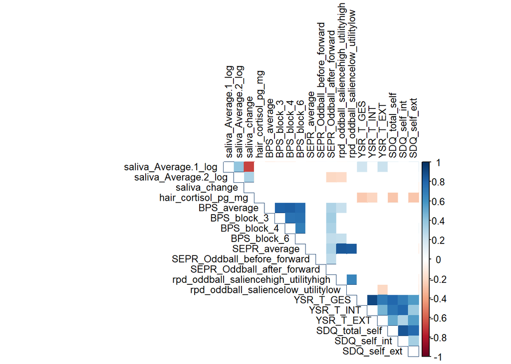

```r
interested_variables<-c(
  "saliva_Average.1_log",
  "saliva_Average.2_log",
  "saliva_change",
  "hair_cortisol_pg_mg",
  "BPS_average",
  #"BPS_block_1",
  #"BPS_block_2",
  "BPS_block_3",
  "BPS_block_4",
  #"BPS_block_5",
  "BPS_block_6",
  #"BPS_Standard_before_forward",
  #"BPS_Standard_before_reverse",
  #"BPS_Standard_after_forward",
  #"BPS_Standard_after_reverse",
  #"pd_low_oddball_saliencehigh_utilityhigh",
  #"pd_low_oddball_saliencehigh_utilitylow",
  #"pd_low_oddball_saliencelow_utilityhigh",
  #"pd_low_oddball_saliencelow_utilitylow",
  "SEPR_average",
  "SEPR_Oddball_before_forward",
  #"SEPR_Oddball_before_reverse",
  "SEPR_Oddball_after_forward",
  #"SEPR_Oddball_after_reverse",
  "rpd_oddball_saliencehigh_utilityhigh",
  #"rpd_oddball_saliencehigh_utilitylow",
  #"rpd_oddball_saliencelow_utilityhigh",
  "rpd_oddball_saliencelow_utilitylow",
  "YSR_T_GES",
  "YSR_T_INT",
  "YSR_T_EXT",
  "SDQ_total_self",
  "SDQ_self_int",
  "SDQ_self_ext"
  # "CBCL_T_GES",
  # "CBCL_T_INT",
  # "CBCL_T_EXT",
  # "SDQ_total_parent",
  # "SDQ_parent_int",
  # "SDQ_parent_ext"
)

data_subset<-df_sample[,interested_variables]
cor_matrix<-round(cor(data_subset,use = 'pairwise.complete.obs'),2)

# Compute p-value matrix
p_matrix <- matrix(NA, nrow = ncol(data_subset), ncol = ncol(data_subset))
rownames(p_matrix) <- colnames(p_matrix) <- colnames(data_subset)

for (i in 1:ncol(data_subset)) {
  for (j in 1:ncol(data_subset)) {
    if (i == j) {
      p_matrix[i, j] <- 1  # p = 1 for self-correlation
    } else if (i < j) {
      # Two-tailed test
      p_val <- cor.test(data_subset[[i]], data_subset[[j]], method = "pearson")$p.value
      p_matrix[i, j] <- p_val
      p_matrix[j, i] <- p_val  # symmetric
    }
  }
}

# Optionally, format p-values for readability (e.g., star notation or rounding)
p_matrix_rounded <- round(p_matrix, 3)

corrplot(
  cor_matrix,
  type = "upper",
  method = 'color',
  tl.cex = 0.8,
  tl.col = "black",
  p.mat = p_matrix_rounded,   # your p-value matrix
  sig.level = 0.05,           # significance threshold
  insig = "blank"              # show non-significant as p-chars or leave blank
)
```

### 1.4.10 correlation pupillometry measures

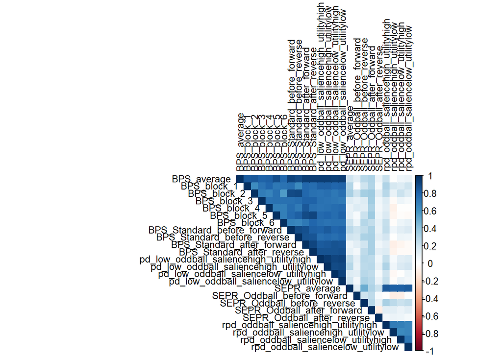

```r
interested_variables<-c(
  "BPS_average",
  "BPS_block_1",
  "BPS_block_2",
  "BPS_block_3",
  "BPS_block_4",
  "BPS_block_5",
  "BPS_block_6",
  "BPS_Standard_before_forward",
  "BPS_Standard_before_reverse",
  "BPS_Standard_after_forward",
  "BPS_Standard_after_reverse",
  "pd_low_oddball_saliencehigh_utilityhigh",
  "pd_low_oddball_saliencehigh_utilitylow",
  "pd_low_oddball_saliencelow_utilityhigh",
  "pd_low_oddball_saliencelow_utilitylow",
  "SEPR_average",
  "SEPR_Oddball_before_forward",
  "SEPR_Oddball_before_reverse",
  "SEPR_Oddball_after_forward",
  "SEPR_Oddball_after_reverse",
  "rpd_oddball_saliencehigh_utilityhigh",
  "rpd_oddball_saliencehigh_utilitylow",
  "rpd_oddball_saliencelow_utilityhigh",
  "rpd_oddball_saliencelow_utilitylow"
)

cor_matrix<-round(cor(df_sample[,interested_variables],use = 'pairwise.complete.obs'),2)
corrplot(cor_matrix,type='upper',method='color',tl.cex=0.8, tl.col='black')
```

### 1.4.11 EFA key measures

```r
interested_variables<-c(
  "saliva_Average.1",
  "saliva_Average.2",
  "hair_cortisol_pg_mg",
  "BPS_block_1",
  "BPS_block_2",
  "BPS_block_3",
  "BPS_block_4",
  "BPS_block_5",
  "BPS_block_6",
  "BPS_Standard_before_forward",
  "BPS_Standard_before_reverse",
  "BPS_Standard_after_forward",
  "BPS_Standard_after_reverse",
  "pd_low_oddball_saliencehigh_utilityhigh",
  "pd_low_oddball_saliencehigh_utilitylow",
  "pd_low_oddball_saliencelow_utilityhigh",
  "pd_low_oddball_saliencelow_utilitylow",
  "SEPR_Oddball_before_forward",
  "SEPR_Oddball_before_reverse",
  "SEPR_Oddball_after_forward",
  "SEPR_Oddball_after_reverse",
  "rpd_oddball_saliencehigh_utilityhigh",
  "rpd_oddball_saliencehigh_utilitylow",
  "rpd_oddball_saliencelow_utilityhigh",
  "rpd_oddball_saliencelow_utilitylow",
  "YSR_T_GES",
  "YSR_T_INT",
  "YSR_T_EXT",
  "SDQ_total_self",
  "SDQ_self_int",
  "SDQ_self_ext",
  "CBCL_T_GES",
  "CBCL_T_INT",
  "CBCL_T_EXT",
  "SDQ_total_parent",
  "SDQ_parent_int",
  "SDQ_parent_ext"
)

# Subset data and remove rows with missing values
pca_data <- df_sample[, interested_variables]
pca_data <- na.omit(pca_data)

# Scale data (recommended for PCA)
pca_data_scaled <- scale(pca_data)

# Determine optimal number of factors (e.g., using parallel analysis)
fa_parallel <- fa.parallel(pca_data_scaled, fa = 'fa', n.iter = 100, sim = F)
```

```
## In smc, smcs < 0 were set to .0
## In smc, smcs < 0 were set to .0
## In smc, smcs < 0 were set to .0
```

```
## In factor.scores, the correlation matrix is singular, the pseudo inverse is  used
```

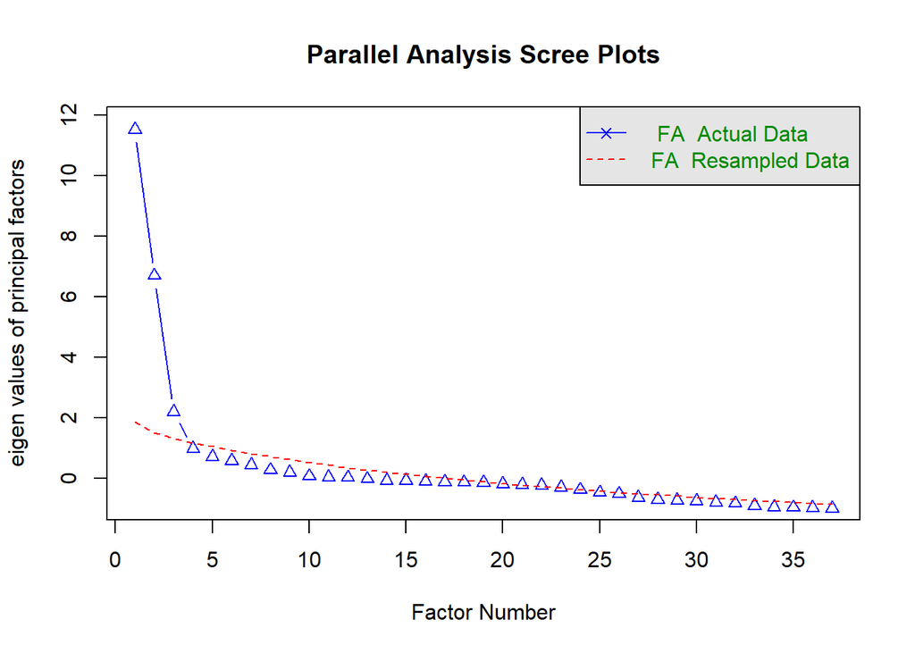

```
## Parallel analysis suggests that the number of factors =  3  and the number of components =  NA
```

```r
print(fa_parallel)
```

```
## Call: fa.parallel(x = pca_data_scaled, fa = "fa", n.iter = 100, sim = F)
## Parallel analysis suggests that the number of factors =  3  and the number of components =  NA
##
##  Eigen Values of
##
##  eigen values of factors
##  [1] 11.52  6.70  2.20  0.98  0.71  0.57  0.43  0.27  0.19  0.07  0.03  0.03
## [13] -0.02 -0.07 -0.07 -0.09 -0.12 -0.13 -0.15 -0.19 -0.21 -0.23 -0.29 -0.38
## [25] -0.47 -0.52 -0.63 -0.71 -0.73 -0.75 -0.79 -0.83 -0.90 -0.95 -0.97 -0.98
## [37] -1.00
##
##  eigen values of simulated factors
## [1] NA
##
##  eigen values of components
##  [1] 11.77  7.67  3.12  1.91  1.60  1.38  1.22  1.05  0.97  0.87  0.72  0.69
## [13]  0.59  0.48  0.36  0.31  0.29  0.28  0.25  0.24  0.21  0.20  0.15  0.13
## [25]  0.11  0.10  0.09  0.06  0.05  0.04  0.03  0.03  0.02  0.02  0.01  0.00
## [37]  0.00
##
##  eigen values of simulated components
## [1] NA
```

```r
# Check if correlation matrix is positive definite
cor_mat <- cor(pca_data_scaled)
eigen_vals <- eigen(cor_mat, only.values = TRUE)$values

if (any(eigen_vals < -1e-10)) {
  message("WARNING: Correlation matrix is NOT positive definite.")
  message("Min eigenvalue: ", round(min(eigen_vals), 4))
} else {
  message("Correlation matrix is OK (all eigenvalues ≥ 0).")
}
```

```
## Correlation matrix is OK (all eigenvalues ≥ 0).
```

```r
# Optional: small regularization to fix near-zero eigenvalues
eps <- 1e-6
cor_mat_pos <- cor_mat + diag(eps, nrow(cor_mat))

# Fit EFA with, e.g., 4 factors (as suggested by your PCA scree plot)
efa_result <- fa(r = cor_mat_pos, nfactors = 6, rotate = 'oblimin',
                 fm = 'ml', scores = 'regression')

# Summary + loading table (with threshold for readability)
print(efa_result$loadings, cut = 0.3)
```

```
##
## Loadings:
##                                         ML4    ML1    ML5    ML6    ML3
## saliva_Average.1                                                     0.410
## saliva_Average.2
## hair_cortisol_pg_mg
## BPS_block_1                              0.833
## BPS_block_2                              0.790
## BPS_block_3                              0.849
## BPS_block_4                              0.875
## BPS_block_5                              0.893
## BPS_block_6                              0.783
## BPS_Standard_before_forward              0.873
## BPS_Standard_before_reverse              0.906
## BPS_Standard_after_forward               0.956
## BPS_Standard_after_reverse               0.958
## pd_low_oddball_saliencehigh_utilityhigh  0.918
## pd_low_oddball_saliencehigh_utilitylow   0.913
## pd_low_oddball_saliencelow_utilityhigh   0.928
## pd_low_oddball_saliencelow_utilitylow    0.933
## SEPR_Oddball_before_forward
## SEPR_Oddball_before_reverse              0.362        -0.345
## SEPR_Oddball_after_forward
## SEPR_Oddball_after_reverse
## rpd_oddball_saliencehigh_utilityhigh                          0.827
## rpd_oddball_saliencehigh_utilitylow                           0.705
## rpd_oddball_saliencelow_utilityhigh                           0.809
## rpd_oddball_saliencelow_utilitylow                            0.813
## YSR_T_GES                                              0.514         0.341
## YSR_T_INT                                              0.684
## YSR_T_EXT                                                            0.502
## SDQ_total_self                                         0.645         0.442
## SDQ_self_int                                           0.940
## SDQ_self_ext                                                         0.921
## CBCL_T_GES                                      0.642
## CBCL_T_INT                                      0.717
## CBCL_T_EXT                                      0.339
## SDQ_total_parent                                0.692
## SDQ_parent_int                                  0.974
## SDQ_parent_ext
```

[output cut: 28 more lines]

```
## YSR_T_EXT
## SDQ_total_self
## SDQ_self_int
## SDQ_self_ext
## CBCL_T_GES
## CBCL_T_INT
## CBCL_T_EXT                               0.468
## SDQ_total_parent                         0.435
## SDQ_parent_int
## SDQ_parent_ext                           0.863
##
##                   ML4   ML1   ML5   ML6   ML3   ML2
## SS loadings    11.363 2.757 2.392 2.833 1.849 1.665
## Proportion Var  0.307 0.075 0.065 0.077 0.050 0.045
## Cumulative Var  0.307 0.382 0.446 0.523 0.573 0.618
```

```r
# Factor correlation matrix (since rotation is oblique)
print(efa_result$Phi, digits = 2)
```

```
##        ML4    ML1    ML5    ML6     ML3     ML2
## ML4 1.0000  0.034  0.099  0.108  0.0048  0.0036
## ML1 0.0338  1.000  0.579 -0.172  0.3513  0.3931
## ML5 0.0988  0.579  1.000 -0.022  0.4291  0.1055
## ML6 0.1080 -0.172 -0.022  1.000 -0.0728 -0.2163
## ML3 0.0048  0.351  0.429 -0.073  1.0000  0.3403
## ML2 0.0036  0.393  0.106 -0.216  0.3403  1.0000
```

### 1.4.12 bivariate associations

```r
#scale numeric variables
df_scaled<-as.data.frame(lapply(df_sample, function(x) {if (is.numeric(x)) scale(x) else x}))

names(df_sample)
```

```
##   [1] "sega_id"
##   [2] "birthday"
##   [3] "gender"
##   [4] "date_data_collection"
##   [5] "group"
##   [6] "sepr_standard_before_forward"
##   [7] "sepr_oddball_before_forward"
##   [8] "sepr_standard_before_reverse"
##   [9] "sepr_oddball_before_reverse"
##  [10] "sepr_standard_after_forward"
##  [11] "sepr_oddball_after_forward"
##  [12] "sepr_standard_after_reverse"
##  [13] "sepr_oddball_after_reverse"
##  [14] "bps_standard_before_forward"
##  [15] "bps_oddball_before_forward"
```

[output cut: 216 more lines]

```r
lm<-lm(saliva_Average.1_log~BPS_average+
         age+gender+autism_boolean,data=df_scaled)
analyze_lm(lm)
```

```
## [1] "adj. R²: 0.01"
## Anova Table (Type III tests)
##
## Response: saliva_Average.1_log
##                Sum Sq Df F value  Pr(>F)
## (Intercept)     0.275  1  0.2740 0.60192
## BPS_average     0.804  1  0.8011 0.37312
## age             2.998  1  2.9870 0.08733 .
## gender          0.191  1  0.1907 0.66336
## autism_boolean  0.227  1  0.2259 0.63570
## Residuals      91.323 91
## ---
## Signif. codes:  0 '***' 0.001 '**' 0.01 '*' 0.05 '.' 0.1 ' ' 1
```

```
##                          2.5 % 97.5 %
## (Intercept)         0.11 -0.29   0.50
## BPS_average        -0.10 -0.32   0.12
## age                 0.20 -0.03   0.42
## genderweiblich     -0.10 -0.57   0.36
## autism_booleanTRUE -0.11 -0.59   0.36
```

```r
save_model(lm,
           var_names = c('Intercept','BPS','age','gender','autism diagnosis','Residuals'),
           caption_label = "Bivariate association of baseline pupil size (BPS) and saliva cortisol concentration (SCC).",
           figure_name = 'Bivariate_assoication_BPS_SCC')

lm<-lm(saliva_Average.2_log~saliva_Average.1_log+
         age+gender+autism_boolean+saliva_Time.1,data=df_scaled)
analyze_lm(lm)
```

```
## [1] "adj. R²: 0.19"
## Anova Table (Type III tests)
##
## Response: saliva_Average.2_log
##                      Sum Sq Df F value    Pr(>F)
## (Intercept)           0.019  1  0.0229 0.8800693
## saliva_Average.1_log 11.158  1 13.4011 0.0004194 ***
## age                   0.977  1  1.1736 0.2815033
## gender                0.104  1  0.1245 0.7250516
## autism_boolean        0.032  1  0.0379 0.8461551
## saliva_Time.1         6.024  1  7.2353 0.0084888 **
## Residuals            76.601 92
## ---
## Signif. codes:  0 '***' 0.001 '**' 0.01 '*' 0.05 '.' 0.1 ' ' 1
```

```
##                            2.5 % 97.5 %
## (Intercept)           0.03 -0.33   0.38
## saliva_Average.1_log  0.36  0.16   0.55
## age                   0.11 -0.09   0.30
## genderweiblich       -0.07 -0.50   0.35
## autism_booleanTRUE    0.04 -0.39   0.47
## saliva_Time.1        -0.26 -0.45  -0.07
```

```r
save_model(lm,
           var_names = c('Intercept','SCC before','age','gender','autism diagnosis','time of day','Residuals'),
           caption_label = "Bivariate association of saliva cortisol concentration (SCC) before and after assessment.",
           figure_name = 'Bivariate_assoication_SCCbefore_SCCafter')
```

### 1.4.13 cortisol and pupillary measures explaining self-reported internalizing

- lower hair cortisol associated with higher internalizing psychopathology
- higher BPS is associated with higher internalizing
- lower SEPR associated with higher internalizing
- higher level interaction of those

```r
lm<-lm(YSR_INT~BPS_block_3*SEPR_average*hair_cortisol_pg_mg_log*saliva_Average.1_log+
         +age+gender+autism_boolean,data=df_scaled)
analyze_lm(lm)
```

```
## [1] "adj. R²: 0.37"
## Anova Table (Type III tests)
##
## Response: YSR_INT
##                                                                       Sum Sq Df
## (Intercept)                                                            2.847  1
## BPS_block_3                                                            7.703  1
## SEPR_average                                                           0.464  1
## hair_cortisol_pg_mg_log                                                4.867  1
## saliva_Average.1_log                                                   3.460  1
## age                                                                    0.607  1
## gender                                                                11.032  1
## autism_boolean                                                         0.361  1
## BPS_block_3:SEPR_average                                               8.216  1
## BPS_block_3:hair_cortisol_pg_mg_log                                    3.940  1
## SEPR_average:hair_cortisol_pg_mg_log                                   0.676  1
## BPS_block_3:saliva_Average.1_log                                       0.774  1
## SEPR_average:saliva_Average.1_log                                      1.023  1
## hair_cortisol_pg_mg_log:saliva_Average.1_log                           2.627  1
## BPS_block_3:SEPR_average:hair_cortisol_pg_mg_log                       0.660  1
## BPS_block_3:SEPR_average:saliva_Average.1_log                          2.753  1
## BPS_block_3:hair_cortisol_pg_mg_log:saliva_Average.1_log               0.042  1
## SEPR_average:hair_cortisol_pg_mg_log:saliva_Average.1_log              1.083  1
## BPS_block_3:SEPR_average:hair_cortisol_pg_mg_log:saliva_Average.1_log  0.117  1
## Residuals                                                             43.936 60
##                                                                       F value
## (Intercept)                                                            3.8886
## BPS_block_3                                                           10.5190
## SEPR_average                                                           0.6342
## hair_cortisol_pg_mg_log                                                6.6462
## saliva_Average.1_log                                                   4.7245
## age                                                                    0.8294
## gender                                                                15.0656
## autism_boolean                                                         0.4934
## BPS_block_3:SEPR_average                                              11.2201
## BPS_block_3:hair_cortisol_pg_mg_log                                    5.3811
## SEPR_average:hair_cortisol_pg_mg_log                                   0.9231
## BPS_block_3:saliva_Average.1_log                                       1.0574
## SEPR_average:saliva_Average.1_log                                      1.3966
## hair_cortisol_pg_mg_log:saliva_Average.1_log                           3.5870
```

[output cut: 35 more lines]

```
## autism_boolean
## BPS_block_3:SEPR_average                                              **
## BPS_block_3:hair_cortisol_pg_mg_log                                   *
## SEPR_average:hair_cortisol_pg_mg_log
## BPS_block_3:saliva_Average.1_log
## SEPR_average:saliva_Average.1_log
## hair_cortisol_pg_mg_log:saliva_Average.1_log                          .
## BPS_block_3:SEPR_average:hair_cortisol_pg_mg_log
## BPS_block_3:SEPR_average:saliva_Average.1_log                         .
## BPS_block_3:hair_cortisol_pg_mg_log:saliva_Average.1_log
## SEPR_average:hair_cortisol_pg_mg_log:saliva_Average.1_log
## BPS_block_3:SEPR_average:hair_cortisol_pg_mg_log:saliva_Average.1_log
## Residuals
## ---
## Signif. codes:  0 '***' 0.001 '**' 0.01 '*' 0.05 '.' 0.1 ' ' 1
```

```
##
## (Intercept)                                                           -0.41
## BPS_block_3                                                            0.37
## SEPR_average                                                          -0.09
## hair_cortisol_pg_mg_log                                               -0.34
## saliva_Average.1_log                                                   0.23
## age                                                                    0.11
## genderweiblich                                                         0.95
## autism_booleanTRUE                                                     0.18
## BPS_block_3:SEPR_average                                              -0.53
## BPS_block_3:hair_cortisol_pg_mg_log                                   -0.27
## SEPR_average:hair_cortisol_pg_mg_log                                   0.14
## BPS_block_3:saliva_Average.1_log                                       0.15
## SEPR_average:saliva_Average.1_log                                     -0.15
## hair_cortisol_pg_mg_log:saliva_Average.1_log                           0.29
## BPS_block_3:SEPR_average:hair_cortisol_pg_mg_log                       0.21
## BPS_block_3:SEPR_average:saliva_Average.1_log                         -0.40
## BPS_block_3:hair_cortisol_pg_mg_log:saliva_Average.1_log              -0.04
## SEPR_average:hair_cortisol_pg_mg_log:saliva_Average.1_log             -0.31
## BPS_block_3:SEPR_average:hair_cortisol_pg_mg_log:saliva_Average.1_log  0.12
##                                                                       2.5 %
## (Intercept)                                                           -0.82
## BPS_block_3                                                            0.14
## SEPR_average                                                          -0.32
## hair_cortisol_pg_mg_log                                               -0.60
## saliva_Average.1_log                                                   0.02
## age                                                                   -0.14
## genderweiblich                                                         0.46
## autism_booleanTRUE                                                    -0.33
## BPS_block_3:SEPR_average                                              -0.85
## BPS_block_3:hair_cortisol_pg_mg_log                                   -0.50
## SEPR_average:hair_cortisol_pg_mg_log                                  -0.15
## BPS_block_3:saliva_Average.1_log                                      -0.14
## SEPR_average:saliva_Average.1_log                                     -0.41
## hair_cortisol_pg_mg_log:saliva_Average.1_log                          -0.02
## BPS_block_3:SEPR_average:hair_cortisol_pg_mg_log                      -0.24
## BPS_block_3:SEPR_average:saliva_Average.1_log                         -0.82
## BPS_block_3:hair_cortisol_pg_mg_log:saliva_Average.1_log              -0.36
## SEPR_average:hair_cortisol_pg_mg_log:saliva_Average.1_log             -0.81
## BPS_block_3:SEPR_average:hair_cortisol_pg_mg_log:saliva_Average.1_log -0.49
##                                                                       97.5 %
## (Intercept)                                                             0.01
## BPS_block_3                                                             0.60
## SEPR_average                                                            0.14
## hair_cortisol_pg_mg_log                                                -0.08
## saliva_Average.1_log                                                    0.45
## age                                                                     0.36
## genderweiblich                                                          1.43
## autism_booleanTRUE                                                      0.68
## BPS_block_3:SEPR_average                                               -0.21
## BPS_block_3:hair_cortisol_pg_mg_log                                    -0.04
## SEPR_average:hair_cortisol_pg_mg_log                                    0.43
## BPS_block_3:saliva_Average.1_log                                        0.44
## SEPR_average:saliva_Average.1_log                                       0.10
## hair_cortisol_pg_mg_log:saliva_Average.1_log                            0.59
## BPS_block_3:SEPR_average:hair_cortisol_pg_mg_log                        0.66
## BPS_block_3:SEPR_average:saliva_Average.1_log                           0.01
## BPS_block_3:hair_cortisol_pg_mg_log:saliva_Average.1_log                0.28
## SEPR_average:hair_cortisol_pg_mg_log:saliva_Average.1_log               0.20
## BPS_block_3:SEPR_average:hair_cortisol_pg_mg_log:saliva_Average.1_log   0.73
```

```r
save_model(lm,
           var_names = c('Intercept','BPS','SEPR','HCC','SCC',
                         'age','gender','autism diagnosis',
                         'BPS x SEPR','BPS x HCC','SEPR x HCC','BPS x SCC','SEPR x SCC',
                         'HCC x SCC','BPS x SEPR x HCC','BPS x SEPR x SCC',
                         'BPS x HCC x SCC','SEPR x HCC x SCC',
                         'BPS x SEPR x HCC x SCC','Residuals'),
           caption_label = "Linear model - combined effects of pupillometry (BPS, SEPR) and cortisol concentration (HCC, SCC) on self-reported Internalizing (YSR Internalizing).",
           figure_name = 'combined_effects_on_YSRint')

### R² = 0.37
emtrends(lm, ~SEPR_average, var="BPS_block_3",
         at = list(SEPR_average = c(-1,1)))
```

```
## NOTE: Results may be misleading due to involvement in interactions
```

```
##  SEPR_average BPS_block_3.trend    SE df lower.CL upper.CL
##            -1             0.895 0.210 60    0.475    1.314
##             1            -0.167 0.177 60   -0.522    0.187
##
## Results are averaged over the levels of: gender, autism_boolean
## Confidence level used: 0.95
```

```r
emtrends(lm, ~hair_cortisol_pg_mg_log, var="BPS_block_3",
         at = list(hair_cortisol_pg_mg_log = c(-1,1)))
```

```
## NOTE: Results may be misleading due to involvement in interactions
```

```
##  hair_cortisol_pg_mg_log BPS_block_3.trend    SE df lower.CL upper.CL
##                       -1            0.6034 0.156 60    0.292    0.915
##                        1            0.0901 0.162 60   -0.235    0.415
##
## Results are averaged over the levels of: gender, autism_boolean
## Confidence level used: 0.95
```

```r
  # #residual normality
  # res_fe<-residuals(lm)
  # hist(res_fe)
  # qqnorm(res_fe)

p<-ggplot(df_scaled, aes(x=BPS_block_3,y=YSR_INT))+
  geom_point(size=2)+
  geom_smooth(method='lm',color='blue')+
  labs(x='arousal (BPS)',y='Internalizing (YSR)')

ggplotly(p)
```

[interactive chart not shown]

```r
p<-ggplot(df_scaled, aes(x=saliva_Average.1_log,y=YSR_INT))+
  geom_point(size=2)+
  geom_smooth(method='lm',color='red')+
  labs(x='saliva cortisol (nmol/l)',y='Internalizing (YSR)')

ggplotly(p)
```

[interactive chart not shown]

```r
p<-ggplot(df_scaled, aes(x=hair_cortisol_pg_mg_log,y=YSR_INT))+
  geom_point(size=2)+
  geom_smooth(method='lm',color='darkgreen')+
  labs(x='hair cortisol (pg/mL)',y='Internalizing (YSR)')

ggplotly(p)
```

[interactive chart not shown]

```r
## SDQ Internalizing
### R² = 0.33
lm<-lm(SDQ_self_int~BPS_block_3*SEPR_average*hair_cortisol_pg_mg_log*saliva_Average.1_log+
         +age+gender+autism_boolean,data=df_scaled)
analyze_lm(lm)
```

```
## [1] "adj. R²: 0.35"
## Anova Table (Type III tests)
##
## Response: SDQ_self_int
##                                                                       Sum Sq Df
## (Intercept)                                                            5.029  1
## BPS_block_3                                                            4.831  1
## SEPR_average                                                           0.314  1
## hair_cortisol_pg_mg_log                                                2.070  1
## saliva_Average.1_log                                                   0.631  1
## age                                                                    1.050  1
## gender                                                                11.140  1
## autism_boolean                                                         3.379  1
## BPS_block_3:SEPR_average                                              11.939  1
## BPS_block_3:hair_cortisol_pg_mg_log                                   11.370  1
## SEPR_average:hair_cortisol_pg_mg_log                                   0.231  1
## BPS_block_3:saliva_Average.1_log                                       0.290  1
## SEPR_average:saliva_Average.1_log                                      0.172  1
## hair_cortisol_pg_mg_log:saliva_Average.1_log                           1.170  1
## BPS_block_3:SEPR_average:hair_cortisol_pg_mg_log                       2.779  1
## BPS_block_3:SEPR_average:saliva_Average.1_log                          0.977  1
## BPS_block_3:hair_cortisol_pg_mg_log:saliva_Average.1_log               0.108  1
## SEPR_average:hair_cortisol_pg_mg_log:saliva_Average.1_log              0.286  1
## BPS_block_3:SEPR_average:hair_cortisol_pg_mg_log:saliva_Average.1_log  0.143  1
## Residuals                                                             40.891 57
##                                                                       F value
## (Intercept)                                                            7.0096
## BPS_block_3                                                            6.7339
## SEPR_average                                                           0.4379
## hair_cortisol_pg_mg_log                                                2.8860
## saliva_Average.1_log                                                   0.8797
## age                                                                    1.4636
## gender                                                                15.5281
## autism_boolean                                                         4.7099
## BPS_block_3:SEPR_average                                              16.6418
## BPS_block_3:hair_cortisol_pg_mg_log                                   15.8497
## SEPR_average:hair_cortisol_pg_mg_log                                   0.3213
## BPS_block_3:saliva_Average.1_log                                       0.4049
## SEPR_average:saliva_Average.1_log                                      0.2399
## hair_cortisol_pg_mg_log:saliva_Average.1_log                           1.6315
```

[output cut: 35 more lines]

```
## autism_boolean                                                        *
## BPS_block_3:SEPR_average                                              ***
## BPS_block_3:hair_cortisol_pg_mg_log                                   ***
## SEPR_average:hair_cortisol_pg_mg_log
## BPS_block_3:saliva_Average.1_log
## SEPR_average:saliva_Average.1_log
## hair_cortisol_pg_mg_log:saliva_Average.1_log
## BPS_block_3:SEPR_average:hair_cortisol_pg_mg_log                      .
## BPS_block_3:SEPR_average:saliva_Average.1_log
## BPS_block_3:hair_cortisol_pg_mg_log:saliva_Average.1_log
## SEPR_average:hair_cortisol_pg_mg_log:saliva_Average.1_log
## BPS_block_3:SEPR_average:hair_cortisol_pg_mg_log:saliva_Average.1_log
## Residuals
## ---
## Signif. codes:  0 '***' 0.001 '**' 0.01 '*' 0.05 '.' 0.1 ' ' 1
```

```
##
## (Intercept)                                                           -0.55
## BPS_block_3                                                            0.30
## SEPR_average                                                           0.08
## hair_cortisol_pg_mg_log                                               -0.22
## saliva_Average.1_log                                                   0.10
## age                                                                   -0.16
## genderweiblich                                                         0.97
## autism_booleanTRUE                                                     0.55
## BPS_block_3:SEPR_average                                              -0.70
## BPS_block_3:hair_cortisol_pg_mg_log                                   -0.48
## SEPR_average:hair_cortisol_pg_mg_log                                   0.09
## BPS_block_3:saliva_Average.1_log                                       0.09
## SEPR_average:saliva_Average.1_log                                     -0.06
## hair_cortisol_pg_mg_log:saliva_Average.1_log                           0.19
## BPS_block_3:SEPR_average:hair_cortisol_pg_mg_log                       0.49
## BPS_block_3:SEPR_average:saliva_Average.1_log                         -0.25
## BPS_block_3:hair_cortisol_pg_mg_log:saliva_Average.1_log              -0.06
## SEPR_average:hair_cortisol_pg_mg_log:saliva_Average.1_log             -0.18
## BPS_block_3:SEPR_average:hair_cortisol_pg_mg_log:saliva_Average.1_log -0.15
##                                                                       2.5 %
## (Intercept)                                                           -0.96
## BPS_block_3                                                            0.07
## SEPR_average                                                          -0.16
## hair_cortisol_pg_mg_log                                               -0.49
## saliva_Average.1_log                                                  -0.11
## age                                                                   -0.43
## genderweiblich                                                         0.48
## autism_booleanTRUE                                                     0.04
## BPS_block_3:SEPR_average                                              -1.05
## BPS_block_3:hair_cortisol_pg_mg_log                                   -0.73
## SEPR_average:hair_cortisol_pg_mg_log                                  -0.22
## BPS_block_3:saliva_Average.1_log                                      -0.20
## SEPR_average:saliva_Average.1_log                                     -0.32
## hair_cortisol_pg_mg_log:saliva_Average.1_log                          -0.11
## BPS_block_3:SEPR_average:hair_cortisol_pg_mg_log                      -0.01
## BPS_block_3:SEPR_average:saliva_Average.1_log                         -0.68
## BPS_block_3:hair_cortisol_pg_mg_log:saliva_Average.1_log              -0.38
## SEPR_average:hair_cortisol_pg_mg_log:saliva_Average.1_log             -0.75
## BPS_block_3:SEPR_average:hair_cortisol_pg_mg_log:saliva_Average.1_log -0.85
##                                                                       97.5 %
## (Intercept)                                                            -0.13
## BPS_block_3                                                             0.53
## SEPR_average                                                            0.32
## hair_cortisol_pg_mg_log                                                 0.04
## saliva_Average.1_log                                                    0.31
## age                                                                     0.10
## genderweiblich                                                          1.47
## autism_booleanTRUE                                                      1.05
## BPS_block_3:SEPR_average                                               -0.36
## BPS_block_3:hair_cortisol_pg_mg_log                                    -0.24
## SEPR_average:hair_cortisol_pg_mg_log                                    0.39
## BPS_block_3:saliva_Average.1_log                                        0.39
## SEPR_average:saliva_Average.1_log                                       0.20
## hair_cortisol_pg_mg_log:saliva_Average.1_log                            0.50
## BPS_block_3:SEPR_average:hair_cortisol_pg_mg_log                        0.98
## BPS_block_3:SEPR_average:saliva_Average.1_log                           0.18
## BPS_block_3:hair_cortisol_pg_mg_log:saliva_Average.1_log                0.26
## SEPR_average:hair_cortisol_pg_mg_log:saliva_Average.1_log               0.39
## BPS_block_3:SEPR_average:hair_cortisol_pg_mg_log:saliva_Average.1_log   0.54
```

```r
save_model(lm,
           var_names = c('Intercept','BPS','SEPR','HCC','SCC change',
                         'age','gender','autism diagnosis',
                         'BPS x SEPR','BPS x HCC','SEPR x HCC','BPS x SCC change','SEPR x SCC change',
                         'HCC x SCC change','BPS x SEPR x HCC','BPS x SEPR x SCC change',
                         'BPS x HCC x SCC change','SEPR x HCC x SCC change',
                         'BPS x SEPR x HCC x SCC change','Residuals'),
           caption_label = "Linear model - combined effects of pupillometry (BPS, SEPR) and cortisol concentration (HCC, SCC change) on self-reported Internalizing (SDQ-s Internalizing).",
           figure_name = 'combined_effects_on_SDQint')
```

### 1.4.14 cortisol and pupillary measures explaining self-reported externalizing

- higher SCC is assoicated with higher Externalizing in YSR and SDQs

```r
#YSR Ext
lm<-lm(YSR_EXT~BPS_block_3*SEPR_average*hair_cortisol_pg_mg_log*saliva_Average.1_log+
         +age+gender+autism_boolean,data=df_scaled)
analyze_lm(lm)
```

```
## [1] "adj. R²: 0"
## Anova Table (Type III tests)
##
## Response: YSR_EXT
##                                                                       Sum Sq Df
## (Intercept)                                                            0.015  1
## BPS_block_3                                                            0.953  1
## SEPR_average                                                           0.624  1
## hair_cortisol_pg_mg_log                                                1.088  1
## saliva_Average.1_log                                                   4.331  1
## age                                                                    0.016  1
## gender                                                                 0.255  1
## autism_boolean                                                         0.022  1
## BPS_block_3:SEPR_average                                               1.230  1
## BPS_block_3:hair_cortisol_pg_mg_log                                    4.237  1
## SEPR_average:hair_cortisol_pg_mg_log                                   0.002  1
## BPS_block_3:saliva_Average.1_log                                       0.002  1
## SEPR_average:saliva_Average.1_log                                      0.579  1
## hair_cortisol_pg_mg_log:saliva_Average.1_log                           0.438  1
## BPS_block_3:SEPR_average:hair_cortisol_pg_mg_log                       0.255  1
## BPS_block_3:SEPR_average:saliva_Average.1_log                          1.737  1
## BPS_block_3:hair_cortisol_pg_mg_log:saliva_Average.1_log               0.007  1
## SEPR_average:hair_cortisol_pg_mg_log:saliva_Average.1_log              0.120  1
## BPS_block_3:SEPR_average:hair_cortisol_pg_mg_log:saliva_Average.1_log  0.399  1
## Residuals                                                             61.622 60
##                                                                       F value
## (Intercept)                                                            0.0147
## BPS_block_3                                                            0.9281
## SEPR_average                                                           0.6077
## hair_cortisol_pg_mg_log                                                1.0594
## saliva_Average.1_log                                                   4.2172
## age                                                                    0.0156
## gender                                                                 0.2485
## autism_boolean                                                         0.0211
## BPS_block_3:SEPR_average                                               1.1973
## BPS_block_3:hair_cortisol_pg_mg_log                                    4.1257
## SEPR_average:hair_cortisol_pg_mg_log                                   0.0023
## BPS_block_3:saliva_Average.1_log                                       0.0020
## SEPR_average:saliva_Average.1_log                                      0.5640
## hair_cortisol_pg_mg_log:saliva_Average.1_log                           0.4267
```

[output cut: 14 more lines]

```
## autism_boolean                                                        0.88504
## BPS_block_3:SEPR_average                                              0.27824
## BPS_block_3:hair_cortisol_pg_mg_log                                   0.04667 *
## SEPR_average:hair_cortisol_pg_mg_log                                  0.96181
## BPS_block_3:saliva_Average.1_log                                      0.96426
## SEPR_average:saliva_Average.1_log                                     0.45560
## hair_cortisol_pg_mg_log:saliva_Average.1_log                          0.51609
## BPS_block_3:SEPR_average:hair_cortisol_pg_mg_log                      0.61982
## BPS_block_3:SEPR_average:saliva_Average.1_log                         0.19842
## BPS_block_3:hair_cortisol_pg_mg_log:saliva_Average.1_log              0.93389
## SEPR_average:hair_cortisol_pg_mg_log:saliva_Average.1_log             0.73404
## BPS_block_3:SEPR_average:hair_cortisol_pg_mg_log:saliva_Average.1_log 0.53565
## Residuals
## ---
## Signif. codes:  0 '***' 0.001 '**' 0.01 '*' 0.05 '.' 0.1 ' ' 1
```

```
##
## (Intercept)                                                           -0.03
## BPS_block_3                                                            0.13
## SEPR_average                                                          -0.11
## hair_cortisol_pg_mg_log                                               -0.16
## saliva_Average.1_log                                                   0.26
## age                                                                   -0.02
## genderweiblich                                                         0.14
## autism_booleanTRUE                                                     0.04
## BPS_block_3:SEPR_average                                              -0.21
## BPS_block_3:hair_cortisol_pg_mg_log                                   -0.28
## SEPR_average:hair_cortisol_pg_mg_log                                  -0.01
## BPS_block_3:saliva_Average.1_log                                       0.01
## SEPR_average:saliva_Average.1_log                                     -0.11
## hair_cortisol_pg_mg_log:saliva_Average.1_log                           0.12
## BPS_block_3:SEPR_average:hair_cortisol_pg_mg_log                       0.13
## BPS_block_3:SEPR_average:saliva_Average.1_log                         -0.32
## BPS_block_3:hair_cortisol_pg_mg_log:saliva_Average.1_log               0.02
## SEPR_average:hair_cortisol_pg_mg_log:saliva_Average.1_log             -0.10
## BPS_block_3:SEPR_average:hair_cortisol_pg_mg_log:saliva_Average.1_log  0.22
##                                                                       2.5 %
## (Intercept)                                                           -0.52
## BPS_block_3                                                           -0.14
## SEPR_average                                                          -0.38
## hair_cortisol_pg_mg_log                                               -0.47
## saliva_Average.1_log                                                   0.01
## age                                                                   -0.31
## genderweiblich                                                        -0.43
## autism_booleanTRUE                                                    -0.56
## BPS_block_3:SEPR_average                                              -0.58
## BPS_block_3:hair_cortisol_pg_mg_log                                   -0.55
## SEPR_average:hair_cortisol_pg_mg_log                                  -0.35
## BPS_block_3:saliva_Average.1_log                                      -0.33
## SEPR_average:saliva_Average.1_log                                     -0.42
## hair_cortisol_pg_mg_log:saliva_Average.1_log                          -0.24
## BPS_block_3:SEPR_average:hair_cortisol_pg_mg_log                      -0.40
## BPS_block_3:SEPR_average:saliva_Average.1_log                         -0.82
## BPS_block_3:hair_cortisol_pg_mg_log:saliva_Average.1_log              -0.37
## SEPR_average:hair_cortisol_pg_mg_log:saliva_Average.1_log             -0.70
## BPS_block_3:SEPR_average:hair_cortisol_pg_mg_log:saliva_Average.1_log -0.50
##                                                                       97.5 %
## (Intercept)                                                             0.46
## BPS_block_3                                                             0.40
## SEPR_average                                                            0.17
## hair_cortisol_pg_mg_log                                                 0.15
## saliva_Average.1_log                                                    0.52
## age                                                                     0.28
## genderweiblich                                                          0.72
## autism_booleanTRUE                                                      0.64
## BPS_block_3:SEPR_average                                                0.17
## BPS_block_3:hair_cortisol_pg_mg_log                                     0.00
## SEPR_average:hair_cortisol_pg_mg_log                                    0.34
## BPS_block_3:saliva_Average.1_log                                        0.35
## SEPR_average:saliva_Average.1_log                                       0.19
## hair_cortisol_pg_mg_log:saliva_Average.1_log                            0.48
## BPS_block_3:SEPR_average:hair_cortisol_pg_mg_log                        0.67
## BPS_block_3:SEPR_average:saliva_Average.1_log                           0.17
## BPS_block_3:hair_cortisol_pg_mg_log:saliva_Average.1_log                0.40
## SEPR_average:hair_cortisol_pg_mg_log:saliva_Average.1_log               0.50
## BPS_block_3:SEPR_average:hair_cortisol_pg_mg_log:saliva_Average.1_log   0.95
```

```r
summary(lm)
```

```
##
## Call:
## lm(formula = YSR_EXT ~ BPS_block_3 * SEPR_average * hair_cortisol_pg_mg_log *
##     saliva_Average.1_log + +age + gender + autism_boolean, data = df_scaled)
##
## Residuals:
##      Min       1Q   Median       3Q      Max
## -2.38192 -0.55463 -0.04363  0.38871  2.74833
##
## Coefficients:
##                                                                        Estimate
## (Intercept)                                                           -0.029691
## BPS_block_3                                                            0.130135
## SEPR_average                                                          -0.106217
## hair_cortisol_pg_mg_log                                               -0.159827
## saliva_Average.1_log                                                   0.261536
## age                                                                   -0.018339
## genderweiblich                                                         0.143876
## autism_booleanTRUE                                                     0.043548
## BPS_block_3:SEPR_average                                              -0.205807
## BPS_block_3:hair_cortisol_pg_mg_log                                   -0.276106
## SEPR_average:hair_cortisol_pg_mg_log                                  -0.008310
## BPS_block_3:saliva_Average.1_log                                       0.007671
## SEPR_average:saliva_Average.1_log                                     -0.113296
## hair_cortisol_pg_mg_log:saliva_Average.1_log                           0.118124
## BPS_block_3:SEPR_average:hair_cortisol_pg_mg_log                       0.133031
## BPS_block_3:SEPR_average:saliva_Average.1_log                         -0.321572
## BPS_block_3:hair_cortisol_pg_mg_log:saliva_Average.1_log               0.015921
## SEPR_average:hair_cortisol_pg_mg_log:saliva_Average.1_log             -0.102162
## BPS_block_3:SEPR_average:hair_cortisol_pg_mg_log:saliva_Average.1_log  0.224727
##                                                                       Std. Error
## (Intercept)                                                             0.244847
## BPS_block_3                                                             0.135083
## SEPR_average                                                            0.136256
## hair_cortisol_pg_mg_log                                                 0.155282
## saliva_Average.1_log                                                    0.127355
## age                                                                     0.146890
## genderweiblich                                                          0.288623
## autism_booleanTRUE                                                      0.299918
## BPS_block_3:SEPR_average                                                0.188088
```

[output cut: 62 more lines]

```
## BPS_block_3:saliva_Average.1_log
## SEPR_average:saliva_Average.1_log
## hair_cortisol_pg_mg_log:saliva_Average.1_log
## BPS_block_3:SEPR_average:hair_cortisol_pg_mg_log
## BPS_block_3:SEPR_average:saliva_Average.1_log
## BPS_block_3:hair_cortisol_pg_mg_log:saliva_Average.1_log
## SEPR_average:hair_cortisol_pg_mg_log:saliva_Average.1_log
## BPS_block_3:SEPR_average:hair_cortisol_pg_mg_log:saliva_Average.1_log
## ---
## Signif. codes:  0 '***' 0.001 '**' 0.01 '*' 0.05 '.' 0.1 ' ' 1
##
## Residual standard error: 1.013 on 60 degrees of freedom
##   (27 observations deleted due to missingness)
## Multiple R-squared:  0.2342, Adjusted R-squared:  0.004512
## F-statistic:  1.02 on 18 and 60 DF,  p-value: 0.4525
```

```r
save_model(lm,
           var_names = c('Intercept','BPS','SEPR','HCC','SCC',
                         'age','gender','autism diagnosis',
                         'BPS x SEPR','BPS x HCC','SEPR x HCC','BPS x SCC','SEPR x SCC',
                         'HCC x SCC','BPS x SEPR x HCC','BPS x SEPR x SCC',
                         'BPS x HCC x SCC','SEPR x HCC x SCC',
                         'BPS x SEPR x HCC x SCC','Residuals'),
           caption_label = "Linear model - combined effects of pupillometry (BPS, SEPR) and cortisol concentration (HCC, SCC change) on self-reported Externalizing (YSR).",
           figure_name = 'combined_effects_on_YSRext')

### R² = 0.17
emtrends(lm, ~hair_cortisol_pg_mg_log, var="BPS_block_3", at = list(hair_cortisol_pg_mg_log = c(-1,1)))
```

```
## NOTE: Results may be misleading due to involvement in interactions
```

```
##  hair_cortisol_pg_mg_log BPS_block_3.trend    SE df lower.CL upper.CL
##                       -1             0.390 0.184 60   0.0212    0.758
##                        1            -0.149 0.192 60  -0.5341    0.236
##
## Results are averaged over the levels of: gender, autism_boolean
## Confidence level used: 0.95
```

```r
p<-ggplot(df_scaled, aes(x=saliva_Average.1_log,y=YSR_EXT))+
  geom_point(size=2)+
  geom_smooth(method='lm',color='orange')+
  labs(x='saliva cortisol (nmol/L)',y='Externalizing (YSR)')

ggplotly(p)
```

[interactive chart not shown]

```r
#SDQ Ext
lm<-lm(SDQ_self_ext~BPS_block_3*SEPR_average*hair_cortisol_pg_mg_log*saliva_Average.1_log+
         +age+gender+autism_boolean,data=df_scaled)
analyze_lm(lm)
```

```
## [1] "adj. R²: 0.06"
## Anova Table (Type III tests)
##
## Response: SDQ_self_ext
##                                                                       Sum Sq Df
## (Intercept)                                                            0.419  1
## BPS_block_3                                                            0.055  1
## SEPR_average                                                           0.112  1
## hair_cortisol_pg_mg_log                                                0.344  1
## saliva_Average.1_log                                                   6.107  1
## age                                                                    2.726  1
## gender                                                                 0.223  1
## autism_boolean                                                         0.217  1
## BPS_block_3:SEPR_average                                               0.804  1
## BPS_block_3:hair_cortisol_pg_mg_log                                    1.342  1
## SEPR_average:hair_cortisol_pg_mg_log                                   0.120  1
## BPS_block_3:saliva_Average.1_log                                       0.044  1
## SEPR_average:saliva_Average.1_log                                      0.996  1
## hair_cortisol_pg_mg_log:saliva_Average.1_log                           0.035  1
## BPS_block_3:SEPR_average:hair_cortisol_pg_mg_log                       0.249  1
## BPS_block_3:SEPR_average:saliva_Average.1_log                          0.844  1
## BPS_block_3:hair_cortisol_pg_mg_log:saliva_Average.1_log               0.440  1
## SEPR_average:hair_cortisol_pg_mg_log:saliva_Average.1_log              1.131  1
## BPS_block_3:SEPR_average:hair_cortisol_pg_mg_log:saliva_Average.1_log  0.181  1
## Residuals                                                             50.868 58
##                                                                       F value
## (Intercept)                                                            0.4778
## BPS_block_3                                                            0.0622
## SEPR_average                                                           0.1280
## hair_cortisol_pg_mg_log                                                0.3928
## saliva_Average.1_log                                                   6.9634
## age                                                                    3.1085
## gender                                                                 0.2540
## autism_boolean                                                         0.2476
## BPS_block_3:SEPR_average                                               0.9171
## BPS_block_3:hair_cortisol_pg_mg_log                                    1.5297
## SEPR_average:hair_cortisol_pg_mg_log                                   0.1364
## BPS_block_3:saliva_Average.1_log                                       0.0507
## SEPR_average:saliva_Average.1_log                                      1.1362
## hair_cortisol_pg_mg_log:saliva_Average.1_log                           0.0397
```

[output cut: 14 more lines]

```
## autism_boolean                                                        0.62062
## BPS_block_3:SEPR_average                                              0.34222
## BPS_block_3:hair_cortisol_pg_mg_log                                   0.22115
## SEPR_average:hair_cortisol_pg_mg_log                                  0.71321
## BPS_block_3:saliva_Average.1_log                                      0.82270
## SEPR_average:saliva_Average.1_log                                     0.29088
## hair_cortisol_pg_mg_log:saliva_Average.1_log                          0.84276
## BPS_block_3:SEPR_average:hair_cortisol_pg_mg_log                      0.59655
## BPS_block_3:SEPR_average:saliva_Average.1_log                         0.33061
## BPS_block_3:hair_cortisol_pg_mg_log:saliva_Average.1_log              0.48154
## SEPR_average:hair_cortisol_pg_mg_log:saliva_Average.1_log             0.26077
## BPS_block_3:SEPR_average:hair_cortisol_pg_mg_log:saliva_Average.1_log 0.65089
## Residuals
## ---
## Signif. codes:  0 '***' 0.001 '**' 0.01 '*' 0.05 '.' 0.1 ' ' 1
```

```
##
## (Intercept)                                                           -0.16
## BPS_block_3                                                            0.03
## SEPR_average                                                          -0.05
## hair_cortisol_pg_mg_log                                               -0.09
## saliva_Average.1_log                                                   0.31
## age                                                                   -0.25
## genderweiblich                                                         0.14
## autism_booleanTRUE                                                     0.14
## BPS_block_3:SEPR_average                                              -0.17
## BPS_block_3:hair_cortisol_pg_mg_log                                   -0.16
## SEPR_average:hair_cortisol_pg_mg_log                                  -0.06
## BPS_block_3:saliva_Average.1_log                                       0.04
## SEPR_average:saliva_Average.1_log                                      0.15
## hair_cortisol_pg_mg_log:saliva_Average.1_log                          -0.03
## BPS_block_3:SEPR_average:hair_cortisol_pg_mg_log                      -0.13
## BPS_block_3:SEPR_average:saliva_Average.1_log                         -0.22
## BPS_block_3:hair_cortisol_pg_mg_log:saliva_Average.1_log               0.13
## SEPR_average:hair_cortisol_pg_mg_log:saliva_Average.1_log             -0.31
## BPS_block_3:SEPR_average:hair_cortisol_pg_mg_log:saliva_Average.1_log  0.15
##                                                                       2.5 %
## (Intercept)                                                           -0.61
## BPS_block_3                                                           -0.22
## SEPR_average                                                          -0.30
## hair_cortisol_pg_mg_log                                               -0.38
## saliva_Average.1_log                                                   0.08
## age                                                                   -0.53
## genderweiblich                                                        -0.40
## autism_booleanTRUE                                                    -0.42
## BPS_block_3:SEPR_average                                              -0.52
## BPS_block_3:hair_cortisol_pg_mg_log                                   -0.41
## SEPR_average:hair_cortisol_pg_mg_log                                  -0.38
## BPS_block_3:saliva_Average.1_log                                      -0.28
## SEPR_average:saliva_Average.1_log                                     -0.13
## hair_cortisol_pg_mg_log:saliva_Average.1_log                          -0.37
## BPS_block_3:SEPR_average:hair_cortisol_pg_mg_log                      -0.63
## BPS_block_3:SEPR_average:saliva_Average.1_log                         -0.68
## BPS_block_3:hair_cortisol_pg_mg_log:saliva_Average.1_log              -0.23
## SEPR_average:hair_cortisol_pg_mg_log:saliva_Average.1_log             -0.87
## BPS_block_3:SEPR_average:hair_cortisol_pg_mg_log:saliva_Average.1_log -0.52
##                                                                       97.5 %
## (Intercept)                                                             0.30
## BPS_block_3                                                             0.28
## SEPR_average                                                            0.21
## hair_cortisol_pg_mg_log                                                 0.20
## saliva_Average.1_log                                                    0.55
## age                                                                     0.03
## genderweiblich                                                          0.67
## autism_booleanTRUE                                                      0.69
## BPS_block_3:SEPR_average                                                0.18
## BPS_block_3:hair_cortisol_pg_mg_log                                     0.10
## SEPR_average:hair_cortisol_pg_mg_log                                    0.26
## BPS_block_3:saliva_Average.1_log                                        0.35
## SEPR_average:saliva_Average.1_log                                       0.43
## hair_cortisol_pg_mg_log:saliva_Average.1_log                            0.30
## BPS_block_3:SEPR_average:hair_cortisol_pg_mg_log                        0.36
## BPS_block_3:SEPR_average:saliva_Average.1_log                           0.23
## BPS_block_3:hair_cortisol_pg_mg_log:saliva_Average.1_log                0.48
## SEPR_average:hair_cortisol_pg_mg_log:saliva_Average.1_log               0.24
## BPS_block_3:SEPR_average:hair_cortisol_pg_mg_log:saliva_Average.1_log   0.82
```

```r
### R² = 0.06

save_model(lm,
           var_names = c('Intercept','BPS','SEPR','HCC','SCC change',
                         'age','gender','autism diagnosis',
                         'BPS x SEPR','BPS x HCC','SEPR x HCC','BPS x SCC change','SEPR x SCC change',
                         'HCC x SCC change','BPS x SEPR x HCC','BPS x SEPR x SCC change',
                         'BPS x HCC x SCC change','SEPR x HCC x SCC change',
                         'BPS x SEPR x HCC x SCC change','Residuals'),
           caption_label = "Linear model - combined effects of pupillometry (BPS, SEPR) and cortisol concentration (HCC, SCC change) on self-reported Externalizing (SDQ-s).",
           figure_name = 'combined_effects_on_SDQext')

emtrends(lm, ~BPS_block_3, var="SEPR_average", at = list(BPS_block_3 = c(-2,-1,0,1,2)))
```

```
## NOTE: Results may be misleading due to involvement in interactions
```

```
##  BPS_block_3 SEPR_average.trend    SE df lower.CL upper.CL
##           -2             0.3080 0.385 58   -0.462    1.078
##           -1             0.1320 0.228 58   -0.324    0.588
##            0            -0.0439 0.127 58   -0.299    0.211
##            1            -0.2199 0.203 58   -0.625    0.186
##            2            -0.3958 0.355 58   -1.107    0.315
##
## Results are averaged over the levels of: gender, autism_boolean
## Confidence level used: 0.95
```

```r
# df_scaled$hair_split<-ifelse(df_scaled$hair_cortisol_pg_mg>=0,'above average hair HCC','below average HCC')
# df_scaled$saliva_split<-ifelse(df_scaled$saliva_Average.1_log>=0,'above average SCC','below average SCC')
# ggplot(df_scaled[!is.na(df_scaled$hair_split) & !is.na(df_scaled$saliva_split),],
#        aes(x=SEPR_average,y=YSR_EXT))+
#   geom_point(size=2)+
#   geom_smooth(method='lm',color='darkgrey')+
#   facet_wrap(~hair_split+saliva_split)+
#   theme(legend.position = 'none')
```

### 1.4.15 classification

- above change classification based on pupillometry and cortisol measures

```r
set.seed(333)

split_ratio<-0.2

df_sample$YSR_INT_CUTOFF<-ifelse(df_sample$YSR_T_INT>=65,T,F)
df_sample$YSR_EXT_CUTOFF<-ifelse(df_sample$YSR_T_EXT>=65,T,F)

# Ensure the target variable is a factor
df_sample$YSR_INT_CUTOFF <- as.factor(df_sample$YSR_INT_CUTOFF)
df_sample$YSR_EXT_CUTOFF <- as.factor(df_sample$YSR_EXT_CUTOFF)


table(df_sample$YSR_INT_CUTOFF)
```

```
##
## FALSE  TRUE
##    64    42
```

```r
table(df_sample$YSR_EXT_CUTOFF)
```

```
##
## FALSE  TRUE
##    99     7
```

```r
table(df_sample$YSR_INT_CUTOFF,df_sample$YSR_EXT_CUTOFF)
```

```
##
##         FALSE TRUE
##   FALSE    61    3
##   TRUE     38    4
```

```r
#complete data
df_sample_complete<-df_sample[complete.cases(df_sample$BPS_block_3) &
                  complete.cases(df_sample$SEPR_average) &
                  complete.cases(df_sample$hair_cortisol_pg_mg_log) &
                  complete.cases(df_sample$saliva_Average.1_log) & complete.cases(df_sample$YSR_INT_CUTOFF),]


#bootstrapping function - cortisol
boot_auc <- function(data, indices) {
  trainIndex <- createDataPartition(data$YSR_INT_CUTOFF, p = split_ratio, list = FALSE)
  testIndex <- createDataPartition(data$YSR_INT_CUTOFF, p = split_ratio, list = FALSE)
  trainData <- df_sample_complete[-trainIndex, ]
  testData <- df_sample_complete[-testIndex, ]
  model <- glm(YSR_INT_CUTOFF ~ hair_cortisol_pg_mg_log*saliva_Average.1_log, data = df_sample_complete, family = binomial)
  probs <- predict(model, newdata = testData, type = "response")
  roc_obj <- roc(testData$YSR_INT_CUTOFF, probs)
  return(auc(roc_obj))
}

# bootstrapping
suppressMessages({boot_results <- boot(data = df_sample_complete, statistic = boot_auc, R = 1000)
})

# Confidence interval for AUC
ci <- boot.ci(boot_results, type = "perc")
print(paste("cortisol AUC:", round(mean(boot_results$t,na.rm=T),3)))
```

```
## [1] "cortisol AUC: 0.659"
```

```r
print(ci)
```

```
## BOOTSTRAP CONFIDENCE INTERVAL CALCULATIONS
## Based on 1000 bootstrap replicates
##
## CALL :
## boot.ci(boot.out = boot_results, type = "perc")
##
## Intervals :
## Level     Percentile
## 95%   ( 0.6011,  0.7286 )
## Calculations and Intervals on Original Scale
```

```r
#bootstrapping function - pupillometry
boot_auc <- function(data, indices) {
  trainIndex <- createDataPartition(data$YSR_INT_CUTOFF, p = split_ratio, list = FALSE)
  testIndex <- createDataPartition(data$YSR_INT_CUTOFF, p = split_ratio, list = FALSE)
  trainData <- df_sample_complete[-trainIndex, ]
  testData <- df_sample_complete[-testIndex, ]
  model <- glm(YSR_INT_CUTOFF ~ BPS_block_3*SEPR_average, data = df_sample_complete, family = binomial)
  probs <- predict(model, newdata = testData, type = "response")
  roc_obj <- roc(testData$YSR_INT_CUTOFF, probs)
  return(auc(roc_obj))
}

# Combine training data and testData for bootstrapping
# (You can also bootstrap on testData if preferred)
suppressMessages({boot_results <- boot(data = df_sample_complete, statistic = boot_auc, R = 1000)
})

# Confidence interval for AUC
ci <- boot.ci(boot_results, type = "perc")
print(paste("pupillometry AUC:", round(mean(boot_results$t,na.rm=T),3)))
```

```
## [1] "pupillometry AUC: 0.666"
```

```r
print(ci)
```

```
## BOOTSTRAP CONFIDENCE INTERVAL CALCULATIONS
## Based on 1000 bootstrap replicates
##
## CALL :
## boot.ci(boot.out = boot_results, type = "perc")
##
## Intervals :
## Level     Percentile
## 95%   ( 0.6032,  0.7341 )
## Calculations and Intervals on Original Scale
```

```r
#bootstrapping function - pupillometry + hair cortisol
boot_auc <- function(data, indices) {
  trainIndex <- createDataPartition(data$YSR_INT_CUTOFF, p = split_ratio, list = FALSE)
  testIndex <- createDataPartition(data$YSR_INT_CUTOFF, p = split_ratio, list = FALSE)
  trainData <- df_sample_complete[-trainIndex, ]
  testData <- df_sample_complete[-testIndex, ]
  model <- glm(YSR_INT_CUTOFF ~ BPS_block_3*SEPR_average*hair_cortisol_pg_mg_log*saliva_Average.1_log, data = df_sample_complete, family = binomial)
  probs <- predict(model, newdata = testData, type = "response")
  roc_obj <- roc(testData$YSR_INT_CUTOFF, probs)
  return(auc(roc_obj))
}

# Combine training data and testData for bootstrapping
# (You can also bootstrap on testData if preferred)
suppressMessages({boot_results <- boot(data = df_sample_complete, statistic = boot_auc, R = 1000)
})

# Confidence interval for AUC
ci <- boot.ci(boot_results, type = "perc")
print(paste("pupillometry + hair cortisol AUC:", round(mean(boot_results$t,na.rm=T),3)))
```

```
## [1] "pupillometry + hair cortisol AUC: 0.861"
```

```r
print(ci)
```

```
## BOOTSTRAP CONFIDENCE INTERVAL CALCULATIONS
## Based on 1000 bootstrap replicates
##
## CALL :
## boot.ci(boot.out = boot_results, type = "perc")
##
## Intervals :
## Level     Percentile
## 95%   ( 0.8195,  0.9038 )
## Calculations and Intervals on Original Scale
```

```r
####FOR EXTERNALIZING

# Bootstrapping function to compute AUC
boot_auc <- function(data, indices) {
  trainIndex <- createDataPartition(data$YSR_EXT_CUTOFF, p = split_ratio, list = FALSE)
  testIndex <- createDataPartition(data$YSR_EXT_CUTOFF, p = split_ratio, list = FALSE)
  trainData <- df_sample_complete[-trainIndex, ]
  testData <- df_sample_complete[-testIndex, ]
  model <- glm(YSR_EXT_CUTOFF ~ BPS_block_3*SEPR_average*hair_cortisol_pg_mg_log*saliva_Average.1_log, data = df_sample_complete, family = binomial)
  probs <- predict(model, newdata = testData, type = "response")
  roc_obj <- roc(testData$YSR_EXT_CUTOFF, probs)
  return(auc(roc_obj))
}

# Combine training data and testData for bootstrapping
# (You can also bootstrap on testData if preferred)
suppressMessages({boot_results <- boot(data = df_sample_complete, statistic = boot_auc, R = 1000)
})

# Confidence interval for AUC
ci <- boot.ci(boot_results, type = "perc")
print(paste("pupillometry + cortisol AUC:", round(mean(boot_results$t,na.rm=T),3)))
```

```
## [1] "pupillometry + cortisol AUC: 0.779"
```

```r
print(ci)
```

```
## BOOTSTRAP CONFIDENCE INTERVAL CALCULATIONS
## Based on 1000 bootstrap replicates
##
## CALL :
## boot.ci(boot.out = boot_results, type = "perc")
##
## Intervals :
## Level     Percentile
## 95%   ( 0.6639,  0.8750 )
## Calculations and Intervals on Original Scale
```